# Final project - Gender Inequality in Income

Group 18: Yunhan Xu, Wei Xiao, Yitian Gong

12-14-2020

##### Package loading

```r
library(tidyverse)
library(knitr)
```

##### Importing the data

```r
# Import starting data
nlsy <- read_csv("http://www.andrew.cmu.edu/user/achoulde/94842/final_project/nlsy97/nlsy97_Nov2020.csv")
```

> In this project, we will examine factors that affect income gap between men and women from seven aspects: parents, education, employment, personalities, values, and marriage and children. For each aspect, we will select 1-2 variables. We rename these variables here: ‘highest_degree’, ‘household_composition’, ‘industry’, ‘disorganized’, ‘trustful’, ‘help_less_fortunate’, ‘take_care_self’, ‘marital_status’, and ‘children_num’.

```r
colnames(nlsy) <- c("PSTRAN_GPA.01_PSTR",
    "INCARC_TOTNUM_XRND",
    "INCARC_AGE_FIRST_XRND",
    "INCARC_LENGTH_LONGEST_XRND",
    "PUBID_1997",
    "YSCH-36400_1997",
    "YSCH-37000_1997",
    "YSAQ-010_1997",
    "YSAQ-369_1997",
    "YEXP-300_1997",
    "YEXP-1500_1997",
    "YEXP-1600_1997",
    "YEXP-1800_1997",
    "YEXP-2000_1997",
    "sex",
    "KEY_BDATE_M_1997",
    "KEY_BDATE_Y_1997",
    "PC8-090_1997",
    "PC8-092_1997",
    "PC9-002_1997",
    "PC12-024_1997",
    "PC12-028_1997",
    "CV_AGE_12/31/96_1997",
    "CV_BIO_MOM_AGE_CHILD1_1997",
    "CV_BIO_MOM_AGE_YOUTH_1997",
    "CV_CITIZENSHIP_1997",
    "CV_ENROLLSTAT_1997",
    "CV_HH_NET_WORTH_P_1997",
    "household_composition",
    "CV_MSA_AGE_12_1997",
    "CV_URBAN-RURAL_AGE_12_1997",
    "CV_SAMPLE_TYPE_1997",
    "CV_HGC_BIO_DAD_1997",
    "CV_HGC_BIO_MOM_1997",
    "CV_HGC_RES_DAD_1997",
    "CV_HGC_RES_MOM_1997",
    "race",
    "YSCH-6800_1998",
    "YSCH-7300_1998",
    "YSAQ-372B_1998",
    "YSAQ-371_2000",
    "disorganized",
    "trustful",
    "CV_HH_NET_WORTH_Y_2003",
    "CV_BA_CREDITS.01_2004",
    "YSAQ-000B_2004",
    "YSAQ-373_2004",
    "YSAQ-369_2005",
    "CV_BIO_CHILD_HH_2007",
    "help_less_fortunate",
    "take_care_self",
    "YTEL-52~000003_2007",
    "YTEL-52~000004_2007",
    "CV_BIO_CHILD_HH_2009",
    "CV_COLLEGE_TYPE.01_2011",
    "CV_INCOME_FAMILY_2011",
    "CV_HH_SIZE_2011",
    "CV_HH_UNDER_18_2011",
    "CV_HH_UNDER_6_2011",
    "highest_degree",
    "CV_BIO_CHILD_HH_2011",
    "YSCH-3112_2011",
    "YSAQ-000A000001_2011",
    "YSAQ-000A000002_2011",
    "YSAQ-000B_2011",
    "YSAQ-360C_2011",
    "YSAQ-364D_2011",
    "YSAQ-371_2011",
    "YSAQ-372CC_2011",
    "YSAQ-373_2011",
    "YSAQ-374_2011",
    "YEMP_INDCODE-2002.01_2011",
    "children_num",
    "industry",
    "YEMP_OCCODE-2002.01_2017",
    "marital_status",
    "YINC-1400_2017",
    "income",
    "YINC-1800_2017",
    "YINC-2400_2017",
    "YINC-2600_2017",
    "YINC-2700_2017",
    "CVC_YTH_REL_HH_AGE6_YCHR_XRND",
    "CVC_SAT_MATH_SCORE_2007_XRND",
    "CVC_SAT_VERBAL_SCORE_2007_XRND",
    "CVC_ACT_SCORE_2007_XRND",
    "CVC_HH_NET_WORTH_20_XRND",
    "CVC_HH_NET_WORTH_25_XRND",
    "CVC_ASSETS_FINANCIAL_25_XRND",
    "CVC_ASSETS_DEBTS_20_XRND",
    "CVC_HH_NET_WORTH_30_XRND",
    "CVC_HOUSE_VALUE_30_XRND",
    "CVC_HOUSE_TYPE_30_XRND",
    "CVC_ASSETS_FINANCIAL_30_XRND",
    "CVC_ASSETS_DEBTS_30_XRND")

### Since all the negative values in the interested variables are NA, we set all negative values to NA.
nlsy[nlsy < 0]  <- NA
```

```r
summary(nlsy$income)
```

```
##    Min. 1st Qu.  Median    Mean 3rd Qu.    Max.    NA's
##       0   25000   40000   49477   62000  235884    3893
```

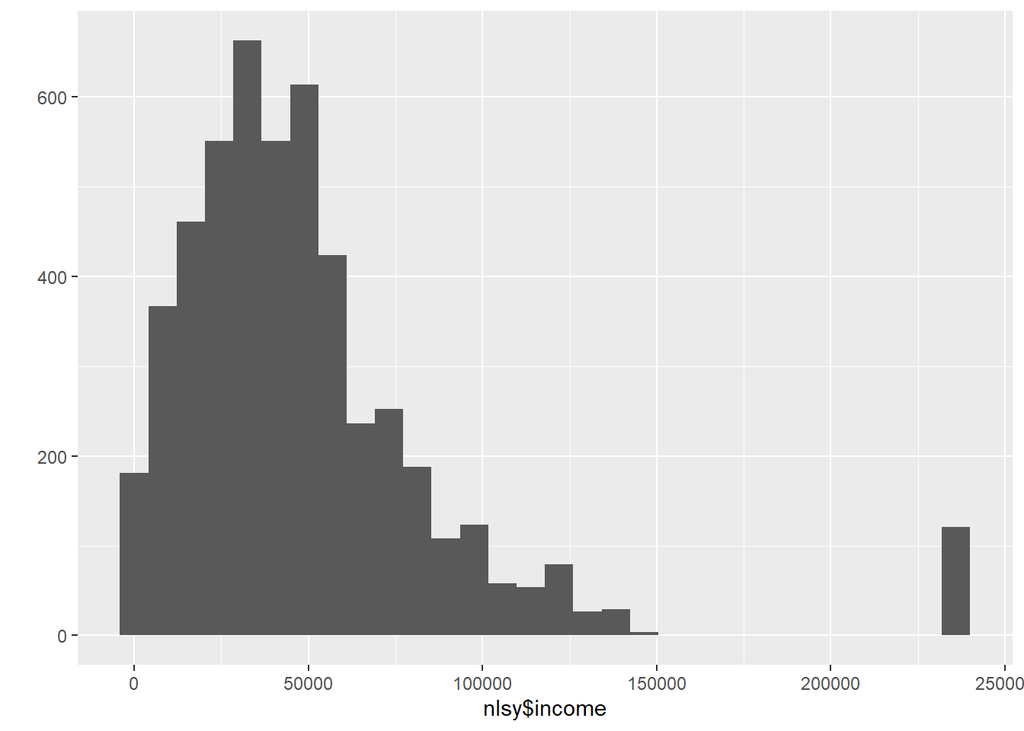

```r
# Histogram
qplot(nlsy$income)
```

```r
n.topcoded <- with(nlsy, sum(income == max(income, na.rm = TRUE), na.rm = TRUE))
n.topcoded
```

```
## [1] 121
```

121 of the incomes are topcoded to the maximum value of 2.3588410^{5}, which is the average value of the top 121 earners.

## Part I: Descriptive Statistics

### a. Pre-processing the data

> Recode variables `sex`, `highest_degree`, `marital_status` and `household composition`. Filter out missing values and zero values in `income`.

```r
nlsy <- nlsy %>%
  mutate(sex = recode_factor(sex,
                                `2` = "Female",
                                `1` = "Male")) %>%
  filter(!is.na(income)) %>%
  filter(income != 0)


nlsy <- nlsy %>% mutate(highest_degree = recode(highest_degree,
                                                     "0" = "None", "1" = "GED",
                                                     "2" = "High School",
                                                     "3" = "Associate/Junior",
                                                     "4" = "Bachelor's",
                                                     "5" = "Master's",
                                                     "6" = "PhD",
                                                     "7" = "Professional"))
nlsy <- nlsy %>%
  mutate(highest_degree = factor(highest_degree,
                                 levels = c("None", "GED", "High School",
                                            "Associate/Junior",
                                            "Bachelor's",
                                            "Master's",
                                            "PhD",
                                            "Professional")))

nlsy <- nlsy %>% mutate(marital_status = recode(marital_status,
                                                "0" = "Never-married",
                                                "1" = "Married",
                                                "2" = "Separated",
                                                "3" = "Divorced",
                                                "4" = "Widowed"))

nlsy <- nlsy %>%
  mutate(marital_status = factor(marital_status,
                                 levels = c("Never-married", "Married", "Separated",
                                            "Divorced", "Widowed")))

nlsy <- nlsy %>%
  mutate(household_composition =
           recode_factor(household_composition,
                         `1` = "Both biological parents",
                         `2` = "Two parents, biological mother",
                         `3` = "Two parents, biological father",
                         `4` = "Biological mother only",
                         `5` = "Biological father only",
                         `6` = "Adoptive parent(s)",
                         `7` = "Foster parent(s)",
                         `8` = "No parents, grandparents",
                         `9` = "No parents, other relatives",
                         `10` = "Anything else"))
```

> Use t-test to identify whether there is a significant difference in income between males and females.

```r
t.test(income ~ sex, data = nlsy)
```

```
##
##  Welch Two Sample t-test
##
## data:  income by sex
## t = -14.347, df = 4850.1, p-value < 2.2e-16
## alternative hypothesis: true difference in means is not equal to 0
## 95 percent confidence interval:
##  -18123.83 -13766.20
## sample estimates:
## mean in group Female   mean in group Male
##             41565.00             57510.01
```

> There is a statistically significant income gap between males and females because the p-value is much lower than 0.05. In this report, we’re going to research how other factors affect the income gap.

### b. Education Level

> To indentify whether income will vary with different degrees, we produce a boxplot to see the minimal income, maximum income, average income, and quatiles for different degrees. We also filter out missing values in `income` and `highest_degree` to prevent producing a boxplot of “NA” group.

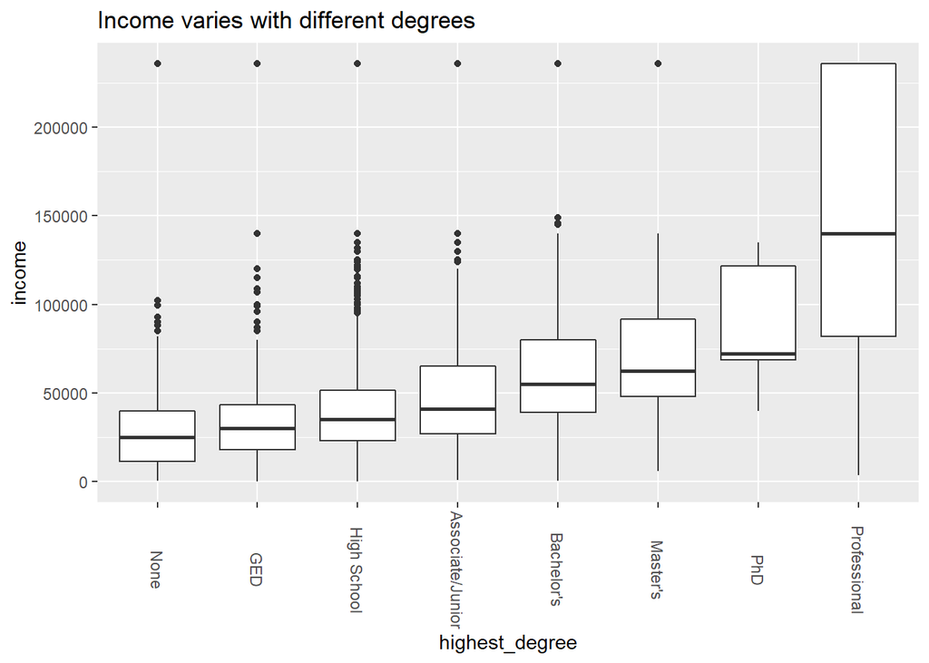

```r
nlsy.copy1 <- nlsy %>% filter(is.na(income) == FALSE,
                              is.na(highest_degree) == FALSE)
ggplot(data = nlsy.copy1, aes(x = highest_degree, y = income)) + geom_boxplot() +
  theme(axis.text.x = element_text(angle = - 90, vjust = 0.5)) +
  ggtitle("Income varies with different degrees")
```

> As we can see from the box plot above, althought there are outliers, generally speaking, minimal income, average income and max income will increase as respondents’ education level increases. Next, we will investigate whether there is income inequality between men and women across different degrees.

> First, produce a bar chart with error bars (confidence intervals) to see the distribution of education levels of men and women.

```r
highest_degree.table <- table(sex = nlsy$sex, highest_degree = nlsy$highest_degree)
highest_degree.df.count <- as_tibble(highest_degree.table)
highest_degree.df.count <- highest_degree.df.count %>%
  group_by(sex) %>%
  mutate(totals = sum(n))

highest_degree.toplot <- highest_degree.df.count %>%
  group_by(highest_degree, sex) %>%
  summarize(prop = n/totals,
            lower = prop.test(n, totals)$conf.int[1],
            upper = prop.test(n, totals)$conf.int[2])
kable(highest_degree.toplot, format = "markdown")
```

| highest_degree | sex | prop | lower | upper |
| --- | --- | --- | --- | --- |
| Associate/Junior | Female | 0.0879931 | 0.0769040 | 0.1004775 |
| Associate/Junior | Male | 0.0711656 | 0.0614425 | 0.0822611 |
| Bachelor’s | Female | 0.2674469 | 0.2495708 | 0.2861055 |
| Bachelor’s | Male | 0.2147239 | 0.1987030 | 0.2316511 |
| GED | Female | 0.0931946 | 0.0817949 | 0.1059715 |
| GED | Male | 0.1231084 | 0.1104781 | 0.1369397 |
| High School | Female | 0.4044213 | 0.3843548 | 0.4248090 |
| High School | Male | 0.4687117 | 0.4487925 | 0.4887300 |
| Master’s | Female | 0.0754226 | 0.0651363 | 0.0871488 |
| Master’s | Male | 0.0425358 | 0.0350424 | 0.0515009 |
| None | Female | 0.0554833 | 0.0466602 | 0.0658185 |
| None | Male | 0.0683027 | 0.0587752 | 0.0792121 |
| PhD | Female | 0.0034677 | 0.0016133 | 0.0071139 |
| PhD | Male | 0.0016360 | 0.0005242 | 0.0044908 |
| Professional | Female | 0.0125704 | 0.0085883 | 0.0182491 |
| Professional | Male | 0.0098160 | 0.0064406 | 0.0148081 |

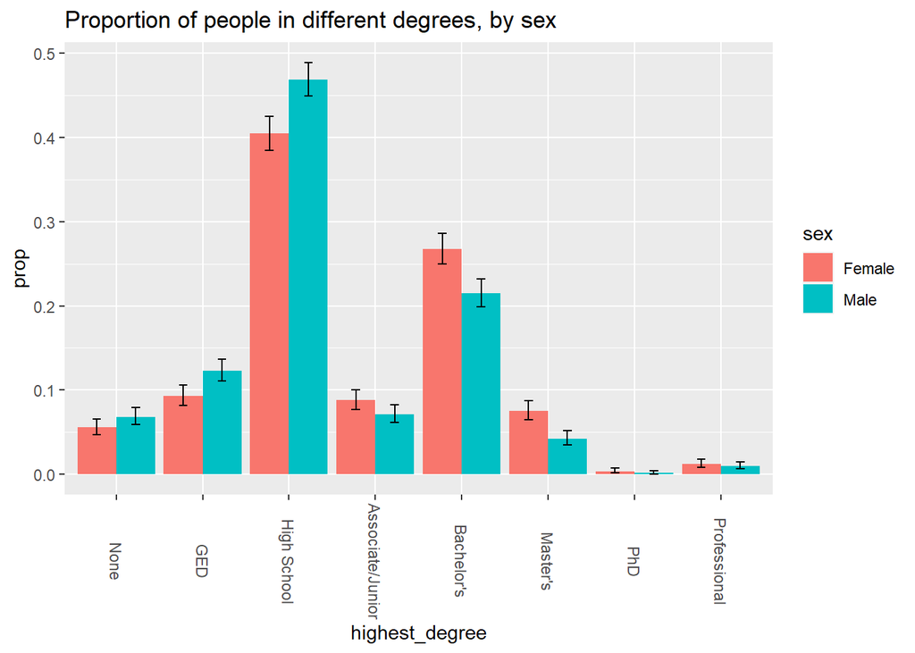

```r
degree_plot <- ggplot(highest_degree.toplot, aes(x = highest_degree, y = prop, fill = sex)) +
  geom_bar(position = 'dodge', stat = 'identity') +
  theme(axis.text.x = element_text(angle = - 90, vjust = 0.5)) +
  geom_errorbar(aes(ymin = lower, ymax = upper),
                width = .2,
                position = position_dodge(0.9)) +
  ggtitle("Proportion of people in different degrees, by sex")

degree_plot + scale_x_discrete(limits = c("None", "GED", "High School",
                                                 "Associate/Junior",
                                                 "Bachelor's",
                                                 "Master's",
                                                 "PhD",
                                                 "Professional"))
```

> The bar chart indicates that the proportions of women who have degrees higher than high school degree are all higher than men. And this proportion difference is statistically significant for bachalor’s degree and master’s degree.

> Construct a modified t-test function that operates in the following way (CI below stands for “confidence interval”):
1. Input: 2 inputs
   - `x`: numeric vector
   - `group`: 2-level factor vector of the same length as `x`
   - `k`: integer, giving minimum group size
   - `flip.sign`: logical. Should CI and mean be flipped?
2. Output: a vector with the following elements:
   - `lower`: the lower value of the error bar (CI)
   - `upper`: the upper value of the error bar (CI)
   - `is.signif`: for groups of size >= `k`, this value should be 0 if CI overlaps 0, and 1 if it doesn’t. For groups of size < `k`, this value should always be 0.
- If `group` has at least `k` observations in each level, return the lower and upper confidence interval values from running `t.test` with formula `x ~ group`.
- If `group` has fewer than `k` observations in one or both levels of this factor, `lower` and `upper` should both be set equal to the mean difference.
- If `flip.sign` = TRUE, the difference and confidence interval should be calculate as group2 - group1 instead of group1 - group2.

```r
betterTTestErrorBars <- function(x, group, k = 5, flip.sign = TRUE) {
  if (length(x) >= k) {
    lower = -t.test(x ~ group)$conf.int[1]
    upper = -t.test(x ~ group)$conf.int[2]
    is.signif = as.numeric(t.test(x ~ group)$p.value < 0.05)
  } else if (length(x) < k) {
    lower = mean(x[1]) - mean(x[2])
    upper = mean(x[1]) - mean(x[2])
    is.signif = 0
  }
  c(lower, upper, is.signif)
}
```

> Produce a bar chart with error bars (confidence intervals) to identity whether there is income inequality between men and women across different degrees. In other words, we’d like to examine whether income gap between men and women varies across different education levels.

```r
education.income.gap <- nlsy %>%
  filter(is.na(highest_degree) == FALSE) %>%
  group_by(highest_degree) %>%
  summarize(income.gap = mean(income[sex == "Male"], na.rm = TRUE) -
              mean(income[sex == "Female"], na.rm = TRUE),
            lower = betterTTestErrorBars(income, sex)[2],
            upper = betterTTestErrorBars(income, sex)[1],
            is.significant = betterTTestErrorBars(income, sex)[3])
education.income.gap <- education.income.gap %>%
  mutate(is.significant = recode_factor(is.significant,
                                        "1" = "Yes",
                                        "0" = "No"))

kable(education.income.gap, format = "markdown")
```

| highest_degree | income.gap | lower | upper | is.significant |
| --- | --- | --- | --- | --- |
| None | 21486.04 | 15850.165 | 27121.91 | Yes |
| GED | 12265.66 | 8288.779 | 16242.55 | Yes |
| High School | 17889.29 | 15650.202 | 20128.37 | Yes |
| Associate/Junior | 12384.58 | 5746.259 | 19022.91 | Yes |
| Bachelor’s | 26891.34 | 21309.862 | 32472.83 | Yes |
| Master’s | 26590.87 | 14592.490 | 38589.25 | Yes |
| PhD | 10750.00 | -57862.418 | 79362.42 | No |
| Professional | 27768.31 | -15435.740 | 70972.35 | No |

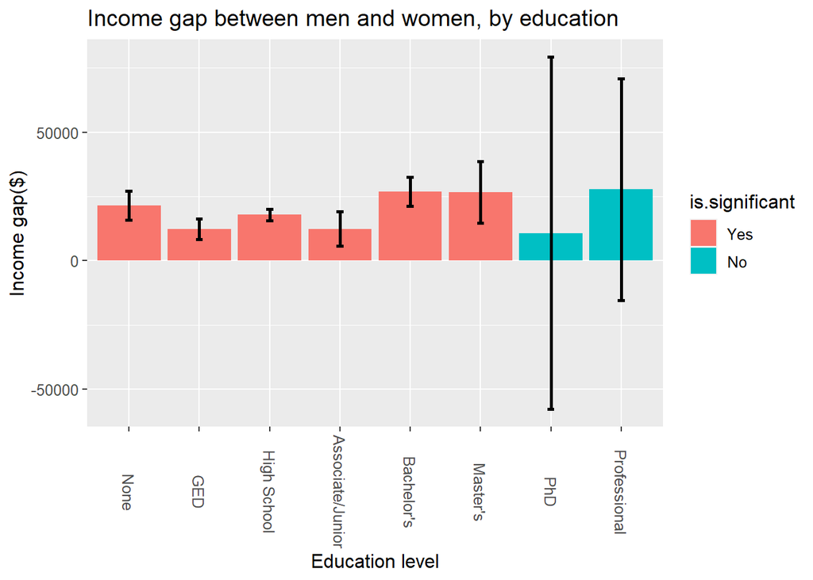

```r
ggplot(education.income.gap,
       aes(x = highest_degree, y = income.gap, fill = is.significant)) +
  geom_bar(stat = "identity") +xlab("Education level") +
  ylab("Income gap($)") +
  ggtitle("Income gap between men and women, by education") +
  guides() +
  geom_errorbar(aes(ymax = upper, ymin = lower), width = 0.1, size = 1) +
  theme(text = element_text(size=12)) +
  theme(axis.text.x = element_text(angle = - 90, vjust = 0.5))
```

> Combined with the previous two pictures, we can conclude that, income increases as education level increases, for both females and males. However, except for PhD and professional degrees, there is statistically significant income inequality between men and women. Besides, although there is no clear trend showing how income gaps increases or decreases as education level increases, education level may be one of the factors affecting income gap as it varies with different degrees. Especially, the income gap among respondents with Bachelor’s degree is bigger than High school degree or Associate/Junior degree.

### c. Marital Status

> Produce a bar chart with error bars to see the distribution of high-income people between men and women across different marital status. (We select never-married as baseline group). Filter out missing values in `income` and `marital_status` to prevent producing a boxplot of “NA” group.

```r
nlsy.copy2 <- nlsy %>% filter(is.na(income) == FALSE,
                              is.na(marital_status) == FALSE)

marriage.prop.income <- nlsy.copy2 %>%
  group_by(marital_status, sex) %>%
  summarize(total = n(), high_income = sum(income > 50000),
            prop = high_income / total,
            lower = prop.test(high_income, total)$conf.int[1],
            upper = prop.test(high_income, total)$conf.int[2])
kable(marriage.prop.income, markdown = "markdown")
```

| marital_status | sex | total | high_income | prop | lower | upper |
| --- | --- | --- | --- | --- | --- | --- |
| Never-married | Female | 896 | 203 | 0.2265625 | 0.1998221 | 0.2556849 |
| Never-married | Male | 1014 | 291 | 0.2869822 | 0.2595077 | 0.3160931 |
| Married | Female | 1191 | 370 | 0.3106633 | 0.2846168 | 0.3379466 |
| Married | Male | 1293 | 737 | 0.5699923 | 0.5424507 | 0.5971133 |
| Separated | Female | 50 | 12 | 0.2400000 | 0.1352167 | 0.3848661 |
| Separated | Male | 56 | 14 | 0.2500000 | 0.1480530 | 0.3864633 |
| Divorced | Female | 290 | 55 | 0.1896552 | 0.1471578 | 0.2405737 |
| Divorced | Male | 223 | 74 | 0.3318386 | 0.2712430 | 0.3983343 |
| Widowed | Female | 14 | 2 | 0.1428571 | 0.0251394 | 0.4384934 |
| Widowed | Male | 3 | 1 | 0.3333333 | 0.0176528 | 0.8746655 |

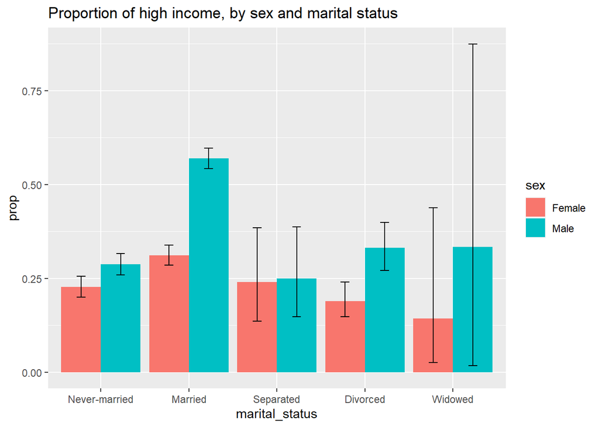

```r
ggplot(marriage.prop.income, aes(x = marital_status, y = prop, fill = sex)) +
  geom_bar(position="dodge", stat="identity") +
  geom_errorbar(aes(ymin = lower, ymax = upper),
                width=.2,
                position=position_dodge(0.9)) +
  ggtitle("Proportion of high income, by sex and marital status")
```

> The graph indicates that for married and divorced respondents, the proportion of high-income men is statistically significantly higher than the proportion of high-income women. Besides, although women and men both have higher proportions of higher income after getting married, the disparity increases a lot after getting married.

> Produce a bar chart with error bars to identity whether there is income inequality between men and women across different marital status.

```r
marriage.income.gap <- nlsy.copy2 %>%
  group_by(marital_status) %>%
  summarize(income.gap = mean(income[sex == "Male"], na.rm = TRUE) -
              mean(income[sex == "Female"], na.rm = TRUE),
            lower = betterTTestErrorBars(income, sex)[2],
            upper = betterTTestErrorBars(income, sex)[1],
            is.significant = betterTTestErrorBars(income, sex)[3])
marriage.income.gap <- marriage.income.gap %>%
  mutate(is.significant = recode_factor(is.significant,
                                        "1" = "Yes",
                                        "0" = "No"))
kable(marriage.income.gap, format = "markdown")
```

| marital_status | income.gap | lower | upper | is.significant |
| --- | --- | --- | --- | --- |
| Never-married | 7304.870 | 4445.717 | 10164.02 | Yes |
| Married | 23540.154 | 20062.465 | 27017.84 | Yes |
| Separated | -2206.357 | -15015.730 | 10603.02 | No |
| Divorced | 13876.071 | 7869.469 | 19882.67 | Yes |
| Widowed | 29904.762 | -35407.976 | 95217.50 | No |

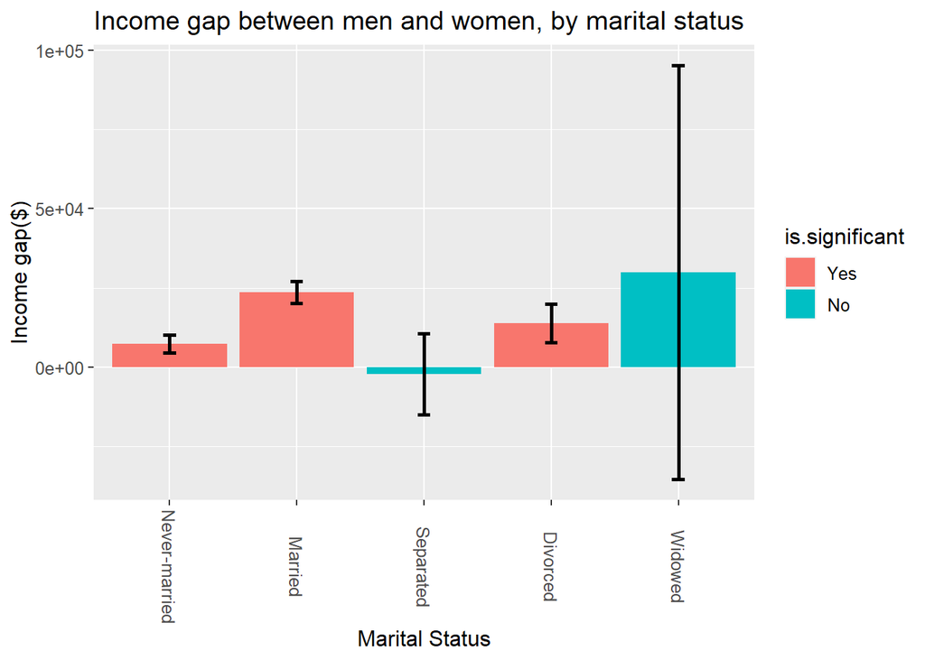

```r
ggplot(marriage.income.gap,
       aes(x = marital_status, y = income.gap, fill = is.significant)) +
  geom_bar(stat = "identity") +xlab("Marital Status") +
  ylab("Income gap($)") +
  ggtitle("Income gap between men and women, by marital status") +
  guides() +
  geom_errorbar(aes(ymax = upper, ymin = lower), width = 0.1, size = 1) +
  theme(text = element_text(size=12)) +
  theme(axis.text.x = element_text(angle = - 90, vjust = 0.5))
```

> For never-married, married, and divorced respondents, males have significantly higher income than females. Especially, the income gap of married respondents is significantly larger than never-married respondents.

### d. Children

> Firstly, use ‘mutate()’ and ‘recode_factor’ functions to recode `children_num` (numeric) to `children` (whether have children or not). Then we will investigate the proportion of high income by sex and whether have children or not. Filter out missing values in `income` and `children_num` to prevent producing a boxplot of “NA” group and other side effects of missing values.

```r
nlsy.copy3 <- nlsy %>% filter(is.na(income) == FALSE, is.na(children_num) == FALSE)
nlsy.copy3 <- nlsy.copy3 %>% mutate(children = recode_factor(children_num,
                                                "0" = "No",
                                                "1" = "Yes",
                                                "2" = "Yes",
                                                "3" = "Yes",
                                                "4" = "Yes",
                                                "5" = "Yes",
                                                "6" = "Yes",
                                                "7" = "Yes",
                                                "8" = "Yes",
                                                "9" = "Yes",
                                                "12" = "Yes"))


child.income <- nlsy.copy3 %>%
  group_by(sex, children) %>% summarize(total = n(), high_income = sum(income > 50000),
            prop = high_income / total,
            lower = prop.test(high_income, total)$conf.int[1],
            upper = prop.test(high_income, total)$conf.int[2])
kable(child.income, format = "markdown")
```

| sex | children | total | high_income | prop | lower | upper |
| --- | --- | --- | --- | --- | --- | --- |
| Female | No | 47 | 7 | 0.1489362 | 0.0668790 | 0.2891936 |
| Female | Yes | 1575 | 320 | 0.2031746 | 0.1837315 | 0.2240851 |
| Male | No | 328 | 67 | 0.2042683 | 0.1627914 | 0.2528292 |
| Male | Yes | 1198 | 618 | 0.5158598 | 0.4871385 | 0.5444781 |

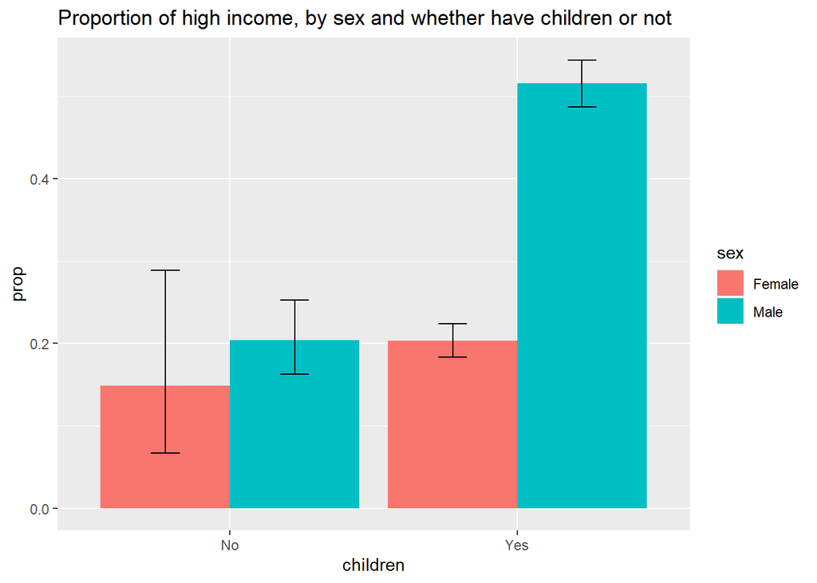

```r
ggplot(child.income, aes(x = children, y = prop, fill = sex)) +
  geom_bar(position="dodge", stat="identity") +
  geom_errorbar(aes(ymin = lower, ymax = upper),
                width=.2,
                position=position_dodge(0.9)) +
  ggtitle("Proportion of high income, by sex and whether have children or not")
```

> The boxplot indicates that the proportion of high-income men is higher than women, no matter whether they have children or not. And this difference is statistically significant for men and women who have children. Besides, although women and men will have higher proportions of high income after having children (probably due to older ages and higher seniority), the proportion difference between the two genders increases a lot.

> Produce a bar chart with error bars to identify whether there is income inequality between men and women depending on whether they have children or not.

```r
child.income.gap <- nlsy.copy3 %>%
  group_by(children) %>%
  summarize(income.gap = mean(income[sex == "Male"], na.rm = TRUE) -
              mean(income[sex == "Female"], na.rm = TRUE),
            lower = betterTTestErrorBars(income, sex)[2],
            upper = betterTTestErrorBars(income, sex)[1],
            is.significant = betterTTestErrorBars(income, sex)[3])
child.income.gap <- child.income.gap %>%
  mutate(is.significant = recode_factor(is.significant,
                                        "1" = "Yes",
                                        "0" = "No"))

kable(child.income.gap, format = "markdown")
```

| children | income.gap | lower | upper | is.significant |
| --- | --- | --- | --- | --- |
| No | 10190.08 | 2399.772 | 17980.38 | Yes |
| Yes | 26596.14 | 23633.500 | 29558.77 | Yes |

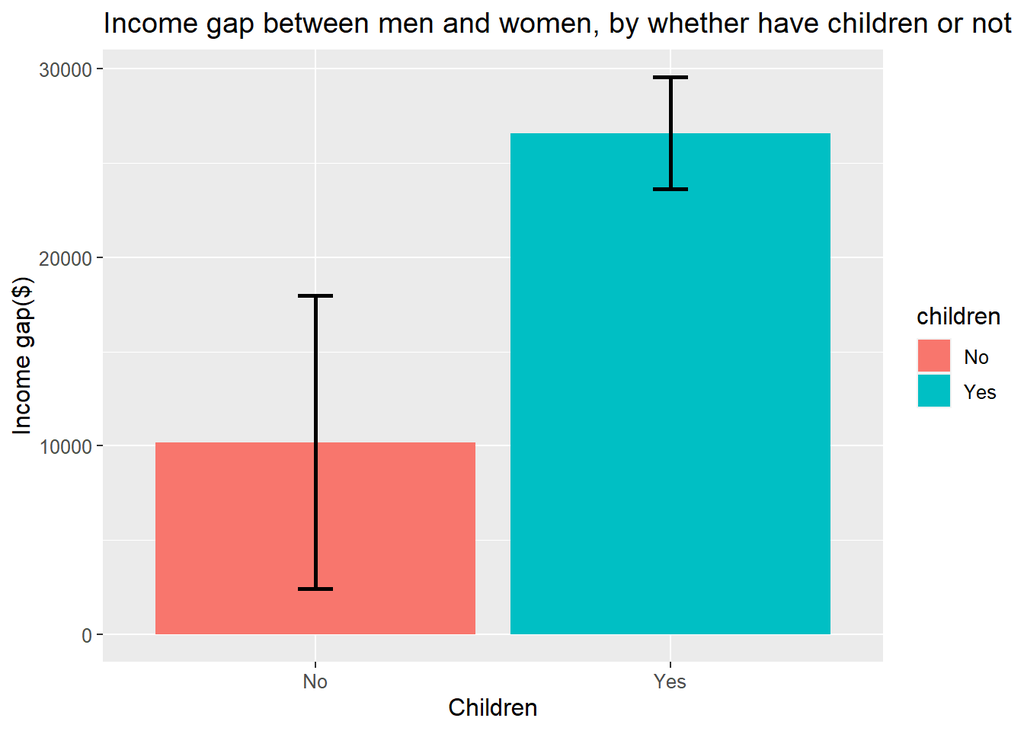

```r
ggplot(child.income.gap,
       aes(x = children, y = income.gap, fill = children)) +
  geom_bar(stat = "identity") +xlab("Children") +
  ylab("Income gap($)") +
  ggtitle("Income gap between men and women, by whether have children or not") +
  guides() +
  geom_errorbar(aes(ymax = upper, ymin = lower), width = 0.1, size = 1) +
  theme(text = element_text(size=12))
```

> The income inequality between men and women is more severe after having children. Whether having children or not may be one of the factors affecting income gap between men and women.

### e. Personalities and Values

In the next section, we are going to examine how males and females differ in their self evaluation of personalities and values, and how personalities and values affect income as well as income gap between males and females.

#### e-1. Personalities

The two variables about personalities are `disorganized` (How much do you feel that disorganized describes you as a person? Where 1 means organized and 5 means disorganized) and `trustful` (How much do you feel that trustful describes you as a person? Where 1 means distrustful and 5 means trustful).

```r
disorganized_char <- nlsy$disorganized
nlsy$disorganized_char <- disorganized_char

# Recode `1` and `2` to "Organized", `3` to "Neutral", and `4` and `5` to "Disorganized"
nlsy <- nlsy %>%
  mutate(disorganized_char = recode_factor(disorganized_char,
                                      `1` = "Organized",
                                      `2` = "Organized",
                                      `3` = "Neutral",
                                      `4` = "Disorganized",
                                      `5` = "Disorganized"))

nlsy <- nlsy %>%
  mutate(disorganized_char = factor(disorganized_char,
                               levels = c("Disorganized",
                                          "Neutral",
                                          "Organized")))

disorganized.table <- table(sex = nlsy$sex, disorganized = nlsy$disorganized_char)
disorganized.df.count <- as_tibble(disorganized.table)
disorganized.df.count <- disorganized.df.count %>%
  group_by(sex) %>%
  mutate(totals = sum(n))

disorganized.toplot <- disorganized.df.count %>%
  group_by(sex, disorganized) %>%
  summarize(prop = n/totals,
            lower = prop.test(n, totals)$conf.int[1],
            upper = prop.test(n, totals)$conf.int[2])
kable(disorganized.toplot, format = "markdown")
```

| sex | disorganized | prop | lower | upper |
| --- | --- | --- | --- | --- |
| Female | Disorganized | 0.1370629 | 0.1198780 | 0.1562307 |
| Female | Neutral | 0.2552448 | 0.2329849 | 0.2788363 |
| Female | Organized | 0.6076923 | 0.5817767 | 0.6330229 |
| Male | Disorganized | 0.1785235 | 0.1595925 | 0.1991363 |
| Male | Neutral | 0.2879195 | 0.2651703 | 0.3117752 |
| Male | Organized | 0.5335570 | 0.5078368 | 0.5591024 |

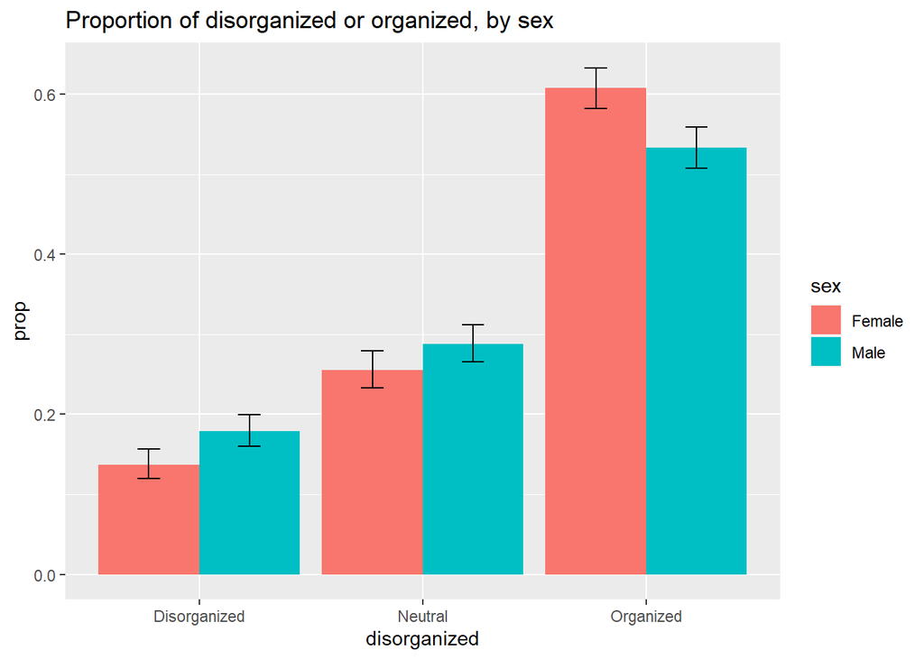

```r
disorganized_plot <- ggplot(disorganized.toplot, aes(x = disorganized, y = prop, fill = sex)) +
  geom_bar(position = 'dodge', stat = 'identity') +
  geom_errorbar(aes(ymin = lower, ymax = upper),
                width = .2,
                position = position_dodge(0.9)) +
  ggtitle("Proportion of disorganized or organized, by sex")

disorganized_plot + scale_x_discrete(limits = c("Disorganized", "Neutral", "Organized"))
```

> For both males and females, more than half of them think themselves as organized, and less than 20% of them think themselves as disorganized. However, higher proportion of females think themselves as organized than males, and this proportion difference is statistically significant.

```r
summary(lm(income ~ disorganized, data = nlsy))
```

```
##
## Call:
## lm(formula = income ~ disorganized, data = nlsy)
##
## Residuals:
##    Min     1Q Median     3Q    Max
## -53199 -23056  -7804  11791 196865
##
## Coefficients:
##              Estimate Std. Error t value Pr(>|t|)
## (Intercept)   56994.6     1798.5  31.690  < 2e-16 ***
## disorganized  -3595.1      684.7  -5.251 1.62e-07 ***
## ---
## Signif. codes:  0 '***' 0.001 '**' 0.01 '*' 0.05 '.' 0.1 ' ' 1
##
## Residual standard error: 37520 on 2918 degrees of freedom
##   (2140 observations deleted due to missingness)
## Multiple R-squared:  0.009361,   Adjusted R-squared:  0.009021
## F-statistic: 27.57 on 1 and 2918 DF,  p-value: 1.622e-07
```

> More organized is associated with higher income. This correlation is statistically significant.

```r
disorganized.conf <- nlsy %>%
  filter(!is.na(disorganized_char)) %>%
  group_by(disorganized_char) %>%
  summarize(income.gap = mean(income[sex == "Male"], na.rm = TRUE) -
              mean(income[sex == "Female"], na.rm = TRUE),
            upper = -t.test(income ~ sex)$conf.int[1],
            lower = -t.test(income ~ sex)$conf.int[2],
            is.significant = as.numeric(t.test(income ~ sex)$p.value < 0.05))
disorganized.conf <- mutate(disorganized.conf,
                        disorganized = reorder(disorganized_char, income.gap))

kable(disorganized.conf, format = "markdown")
```

| disorganized_char | income.gap | upper | lower | is.significant | disorganized |
| --- | --- | --- | --- | --- | --- |
| Disorganized | 12961.41 | 18658.27 | 7264.552 | 1 | Disorganized |
| Neutral | 11110.58 | 15943.78 | 6277.388 | 1 | Neutral |
| Organized | 14354.27 | 18156.36 | 10552.176 | 1 | Organized |

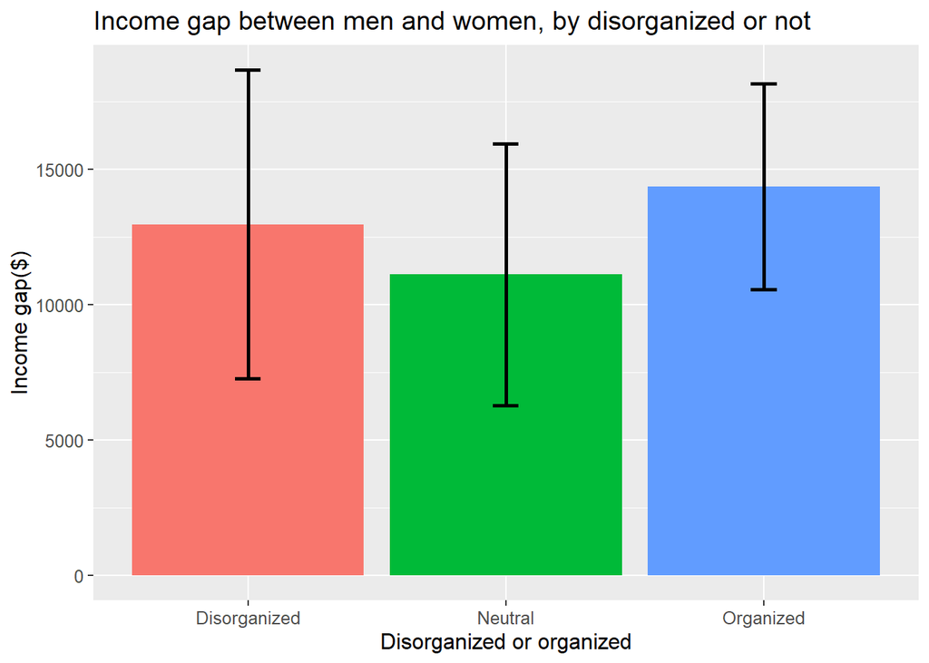

```r
ggplot(data = disorganized.conf, aes(x = disorganized_char, y = income.gap,
                            fill = disorganized_char)) +
  geom_bar(stat = "identity") +
  xlab("Disorganized or organized") +
  ylab("Income gap($)") +
  ggtitle("Income gap between men and women, by disorganized or not") +
  guides(fill = FALSE) +
  geom_errorbar(aes(ymax = upper, ymin = lower), width = 0.1, size = 1) +
  theme(text = element_text(size=12))
```

> Whether the respondents think themselves as disorganized or organized, males have significantly higher income than females. But the income gaps do not seem to vary across groups.

```r
trustful_char <- nlsy$trustful
nlsy$trustful_char <- trustful_char

# recode `1` and `2` to "Not trustful", `3` to "Neutral", and `4` and `5` to "Trustful"
nlsy <- nlsy %>%
  mutate(trustful_char = recode_factor(trustful_char,
                                      `1` = "Not trustful",
                                      `2` = "Not trustful",
                                      `3` = "Neutral",
                                      `4` = "Trustful",
                                      `5` = "Trustful"))

nlsy <- nlsy %>%
  mutate(trustful_char = factor(trustful_char,
                           levels = c("Not trustful",
                                      "Neutral",
                                      "Trustful")))

trustful <- table(sex = nlsy$sex, trustful = nlsy$trustful_char)
trustful.df.count <- as_tibble(trustful)
trustful.df.count <- trustful.df.count %>%
  group_by(sex) %>%
  mutate(totals = sum(n))

trustful.toplot <- trustful.df.count %>%
  group_by(sex, trustful) %>%
  summarize(prop = n/totals,
            lower = prop.test(n, totals)$conf.int[1],
            upper = prop.test(n, totals)$conf.int[2])
kable(trustful.toplot, format = "markdown")
```

| sex | trustful | prop | lower | upper |
| --- | --- | --- | --- | --- |
| Female | Neutral | 0.0461538 | 0.0361318 | 0.0586853 |
| Female | Not trustful | 0.0566434 | 0.0454932 | 0.0702380 |
| Female | Trustful | 0.8972028 | 0.8800111 | 0.9122191 |
| Male | Neutral | 0.0549966 | 0.0442256 | 0.0681208 |
| Male | Not trustful | 0.0650570 | 0.0533179 | 0.0790911 |
| Male | Trustful | 0.8799463 | 0.8621102 | 0.8957901 |

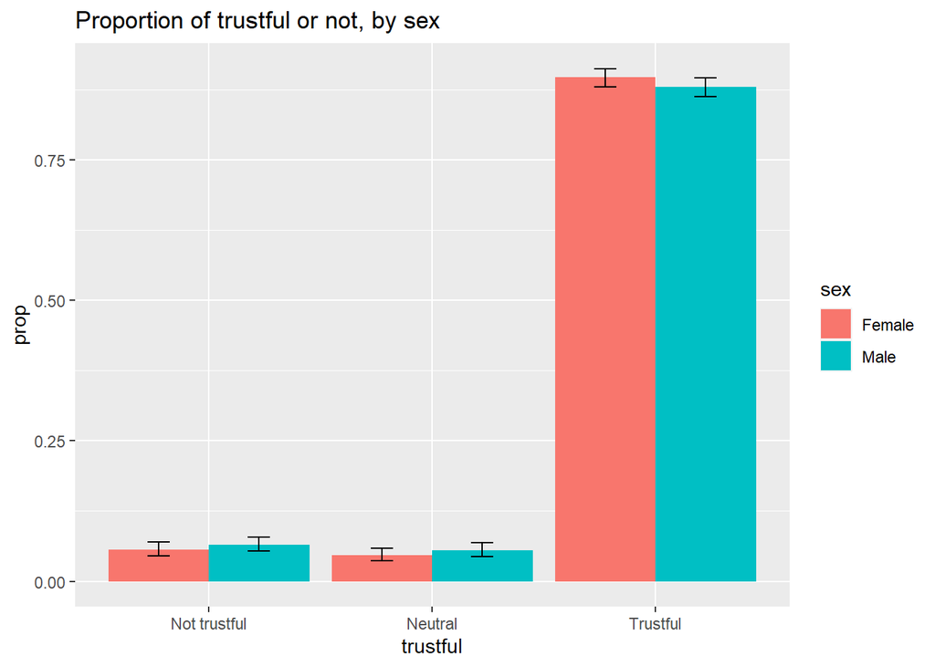

```r
trustful_plot <- ggplot(trustful.toplot, aes(x = trustful, y = prop, fill = sex)) +
  geom_bar(position = 'dodge', stat = 'identity') +
  geom_errorbar(aes(ymin = lower, ymax = upper),
                width = .2,
                position = position_dodge(0.9)) +
  ggtitle("Proportion of trustful or not, by sex")

trustful_plot + scale_x_discrete(limits = c("Not trustful", "Neutral", "Trustful"))
```

> For both males and females, more than 85% of them think themselves as trustful. Slightly higher proportion of females think themselves as trustful than males, but this difference is not statistically significant.

```r
summary(lm(income ~ trustful, data = nlsy))
```

```
##
## Call:
## lm(formula = income ~ trustful, data = nlsy)
##
## Residuals:
##    Min     1Q Median     3Q    Max
## -49016 -23141  -7653  11834 191256
##
## Coefficients:
##             Estimate Std. Error t value Pr(>|t|)
## (Intercept)  41602.1     3405.6  12.216   <2e-16 ***
## trustful      1512.8      755.3   2.003   0.0453 *
## ---
## Signif. codes:  0 '***' 0.001 '**' 0.01 '*' 0.05 '.' 0.1 ' ' 1
##
## Residual standard error: 37660 on 2919 degrees of freedom
##   (2139 observations deleted due to missingness)
## Multiple R-squared:  0.001373,   Adjusted R-squared:  0.00103
## F-statistic: 4.012 on 1 and 2919 DF,  p-value: 0.04527
```

> More trustful is associated with higher income. This correlation is statistically significant.

```r
trustful.conf <- nlsy %>%
  filter(!is.na(trustful_char)) %>%
  group_by(trustful_char) %>%
  summarize(income.gap = mean(income[sex == "Male"], na.rm = TRUE) -
              mean(income[sex == "Female"], na.rm = TRUE),
            upper = -t.test(income ~ sex)$conf.int[1],
            lower = -t.test(income ~ sex)$conf.int[2],
            is.significant = as.numeric(t.test(income ~ sex)$p.value < 0.05))
trustful.conf <- mutate(trustful.conf,
                        trustful = reorder(trustful_char, income.gap))

kable(trustful.conf, format = "markdown")
```

| trustful_char | income.gap | upper | lower | is.significant | trustful |
| --- | --- | --- | --- | --- | --- |
| Not trustful | 9207.577 | 19425.26 | -1010.1078 | 0 | Not trustful |
| Neutral | 12389.347 | 25110.40 | -331.7003 | 0 | Neutral |
| Trustful | 12958.440 | 15810.16 | 10106.7197 | 1 | Trustful |

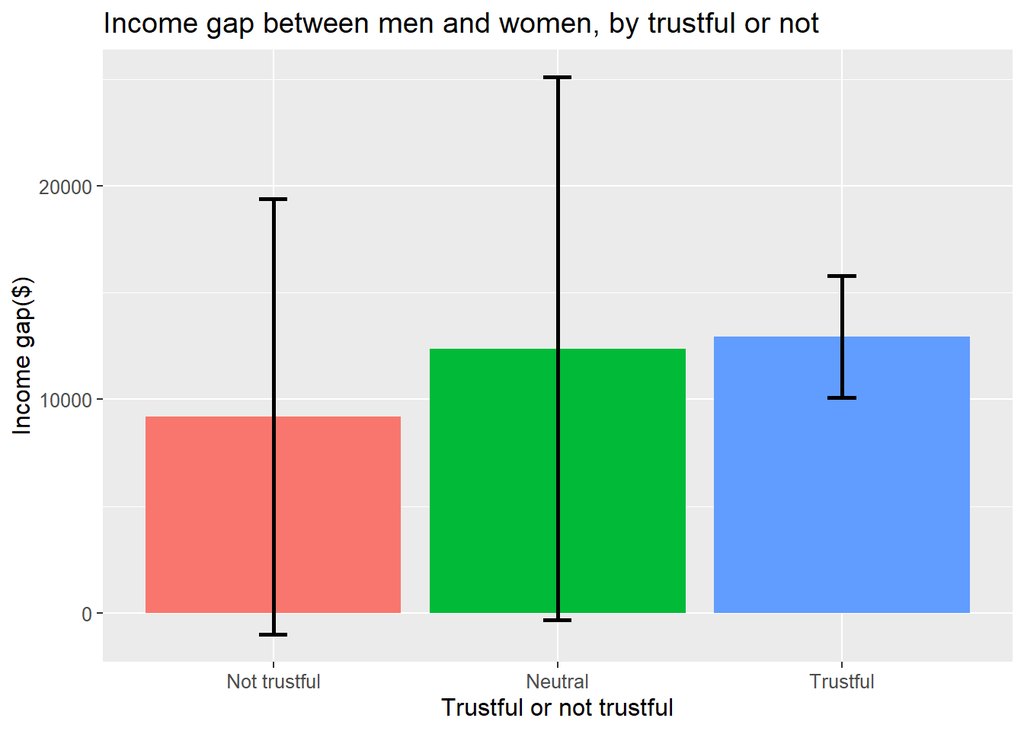

```r
ggplot(data = trustful.conf, aes(x = trustful_char, y = income.gap,
                            fill = trustful_char)) +
  geom_bar(stat = "identity") +
  xlab("Trustful or not trustful") +
  ylab("Income gap($)") +
  ggtitle("Income gap between men and women, by trustful or not") +
  guides(fill = FALSE) +
  geom_errorbar(aes(ymax = upper, ymin = lower), width = 0.1, size = 1) +
  theme(text = element_text(size=12))
```

> For respondents who think themselves as not trustful or neutral, the confidence interval of income gaps between males and females both include an zero, indicating that the income gaps for the two groups are not statistically significant. However, for respondents who think themselves as trustful, the income gap is significant.

#### e-2. Values

> The two variables for values are `help_less_fortunate` (How much do you agree that people should be willing to help others who are less fortunate? Where 0 means strongly disagree and 4 means strongly agree) and `take_care_self` (How much do you agree that those in need have to learn to take care of themselves and not depend on others? Where 0 means strongly disagree and 4 means strongly agree).

```r
help_less_fortunate_char <- nlsy$help_less_fortunate
nlsy$help_less_fortunate_char <- help_less_fortunate_char

# recode `0` and `1` to "Disagree", `2` to "Neutral", and `3` and `4` to "Agree"
nlsy <- nlsy %>%
  mutate(help_less_fortunate_char = recode_factor(help_less_fortunate_char,
                                      `0` = "Disagree",
                                      `1` = "Disagree",
                                      `2` = "Neutral",
                                      `3` = "Agree",
                                      `4` = "Agree"))

nlsy <- nlsy %>%
  mutate(help_less_fortunate_char = factor(help_less_fortunate_char,
                           levels = c("Disagree",
                                      "Neutral",
                                      "Agree")))

help_less_fortunate <- table(sex = nlsy$sex,
                             help_less_fortunate = nlsy$help_less_fortunate_char)
help_less_fortunate.df.count <- as_tibble(help_less_fortunate)
help_less_fortunate.df.count <- help_less_fortunate.df.count %>%
  group_by(sex) %>%
  mutate(totals = sum(n))

help_less_fortunate.toplot <- help_less_fortunate.df.count %>%
  group_by(sex, help_less_fortunate) %>%
  summarize(prop = n/totals,
            lower = prop.test(n, totals)$conf.int[1],
            upper = prop.test(n, totals)$conf.int[2])
kable(help_less_fortunate.toplot, format = "markdown")
```

| sex | help_less_fortunate | prop | lower | upper |
| --- | --- | --- | --- | --- |
| Female | Agree | 0.9590018 | 0.9381824 | 0.9732459 |
| Female | Disagree | 0.0089127 | 0.0032858 | 0.0219205 |
| Female | Neutral | 0.0320856 | 0.0196959 | 0.0512184 |
| Male | Agree | 0.9411765 | 0.9183314 | 0.9581135 |
| Male | Disagree | 0.0117647 | 0.0051648 | 0.0251981 |
| Male | Neutral | 0.0470588 | 0.0320633 | 0.0681474 |

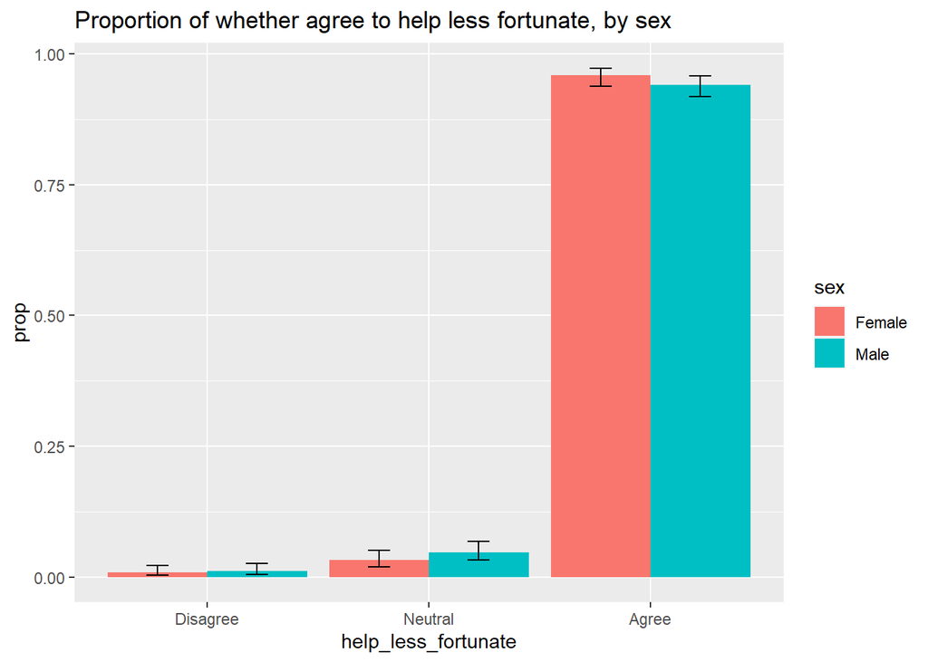

```r
help_plot <- ggplot(help_less_fortunate.toplot,
       aes(x = help_less_fortunate, y = prop, fill = sex)) +
  geom_bar(position = 'dodge', stat = 'identity') +
  geom_errorbar(aes(ymin = lower, ymax = upper),
                width = .2,
                position = position_dodge(0.9)) +
  ggtitle("Proportion of whether agree to help less fortunate, by sex")

help_plot + scale_x_discrete(limits = c("Disagree", "Neutral", "Agree"))
```

> For both males and females, very few of them disagree that people should help less fortunate people. But higher proportion of females agree than males. Though this difference is not statistically significant.

```r
summary(lm(income ~ help_less_fortunate, data = nlsy))
```

```
##
## Call:
## lm(formula = income ~ help_less_fortunate, data = nlsy)
##
## Residuals:
##    Min     1Q Median     3Q    Max
## -49563 -23679  -9100  12164 188048
##
## Coefficients:
##                     Estimate Std. Error t value Pr(>|t|)
## (Intercept)            52889       6287   8.413   <2e-16 ***
## help_less_fortunate    -1263       1826  -0.692    0.489
## ---
## Signif. codes:  0 '***' 0.001 '**' 0.01 '*' 0.05 '.' 0.1 ' ' 1
##
## Residual standard error: 38730 on 1154 degrees of freedom
##   (3904 observations deleted due to missingness)
## Multiple R-squared:  0.0004143,  Adjusted R-squared:  -0.0004519
## F-statistic: 0.4783 on 1 and 1154 DF,  p-value: 0.4893
```

> The correlation between how much a respondent agree to the statement that people should help less fortunate and income is not statistically significant.

```r
help_less_fortunate.conf <- nlsy %>%
  filter(!is.na(help_less_fortunate_char)) %>%
  group_by(help_less_fortunate_char) %>%
  summarize(income.gap = mean(income[sex == "Male"], na.rm = TRUE) -
              mean(income[sex == "Female"], na.rm = TRUE),
            upper = -t.test(income ~ sex)$conf.int[1],
            lower = -t.test(income ~ sex)$conf.int[2],
            is.significant = as.numeric(t.test(income ~ sex)$p.value < 0.05))
help_less_fortunate.conf <- mutate(help_less_fortunate.conf,
                        help_less_fortunate = reorder(help_less_fortunate_char, income.gap))

kable(help_less_fortunate.conf, format = "markdown")
```

| help_less_fortunate_char | income.gap | upper | lower | is.significant | help_less_fortunate |
| --- | --- | --- | --- | --- | --- |
| Disagree | 53974.51 | 81833.64 | 26115.390 | 1 | Disagree |
| Neutral | 29085.60 | 51755.91 | 6415.294 | 1 | Neutral |
| Agree | 14327.03 | 18789.76 | 9864.305 | 1 | Agree |

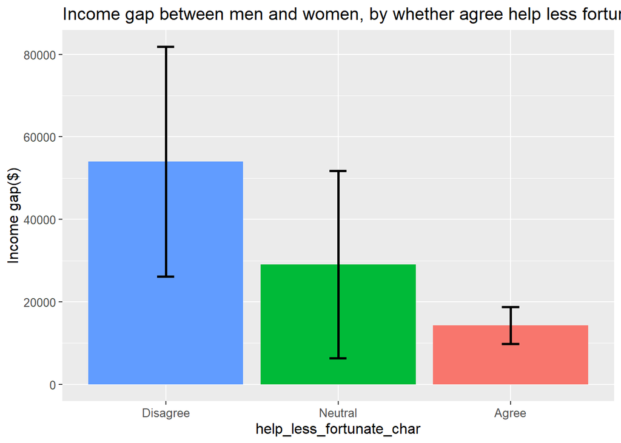

```r
ggplot(data = help_less_fortunate.conf, aes(x = help_less_fortunate_char, y = income.gap,
                            fill = help_less_fortunate)) +
  geom_bar(stat = "identity") +
  ylab("Income gap($)") +
  ggtitle("Income gap between men and women, by whether agree help less fortunate") +
  guides(fill = FALSE) +
  geom_errorbar(aes(ymax = upper, ymin = lower), width = 0.1, size = 1) +
  theme(text = element_text(size=12))
```

> Whether the respondents agree that people should help less fortunate people, males have significantly higher income than females. Especially, for respondents who disagree with this statement, the income gap is significantly bigger than respondents who agree.

```r
take_care_self_char <- nlsy$take_care_self
nlsy$take_care_self_char <- take_care_self_char

# recode `0` and `1` to "Disagree", `2` to "Neutral", and `3` and `4` to "Agree"
nlsy <- nlsy %>%
  mutate(take_care_self_char = recode_factor(take_care_self_char,
                                      `0` = "Disagree",
                                      `1` = "Disagree",
                                      `2` = "Neutral",
                                      `3` = "Agree",
                                      `4` = "Agree"))

nlsy <- nlsy %>%
  mutate(take_care_self_char = factor(take_care_self_char,
                           levels = c("Disagree",
                                      "Neutral",
                                      "Agree")))

take_care_self <- table(sex = nlsy$sex,
                              take_care_self = nlsy$ take_care_self_char)
take_care_self.df.count <- as_tibble(take_care_self)
take_care_self.df.count <- take_care_self.df.count %>%
  group_by(sex) %>%
  mutate(totals = sum(n))

take_care_self.toplot <- take_care_self.df.count %>%
  group_by(sex, take_care_self) %>%
  summarize(prop = n/totals,
            lower = prop.test(n, totals)$conf.int[1],
            upper = prop.test(n, totals)$conf.int[2])
kable(take_care_self.toplot, format = "markdown")
```

| sex | take_care_self | prop | lower | upper |
| --- | --- | --- | --- | --- |
| Female | Agree | 0.5527728 | 0.5104386 | 0.5943711 |
| Female | Disagree | 0.2361360 | 0.2019611 | 0.2740037 |
| Female | Neutral | 0.2110912 | 0.1784556 | 0.2477743 |
| Male | Agree | 0.6486486 | 0.6084865 | 0.6868521 |
| Male | Disagree | 0.1993243 | 0.1683391 | 0.2342878 |
| Male | Neutral | 0.1520270 | 0.1245801 | 0.1840910 |

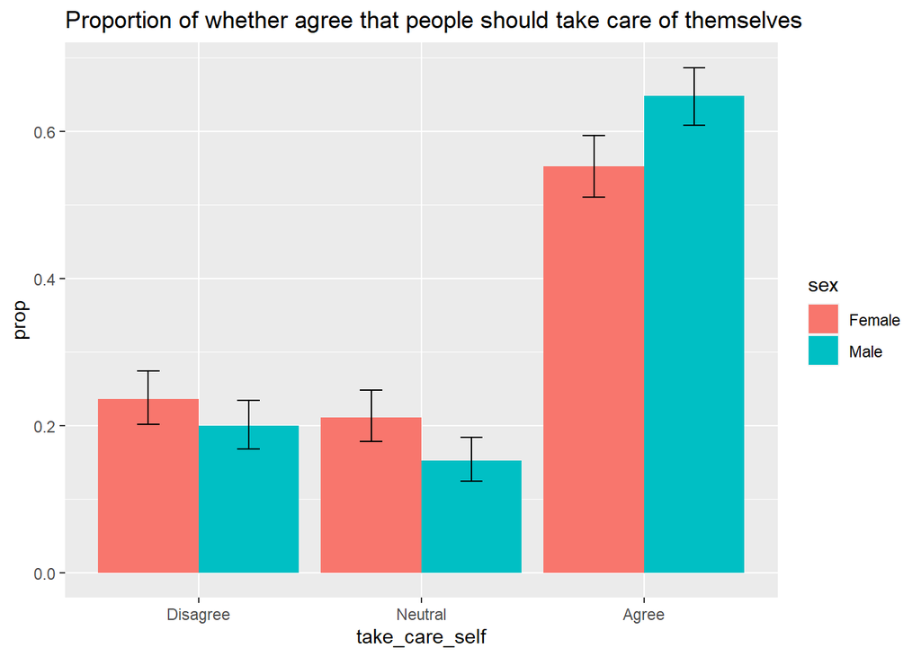

```r
takecare_plot <- ggplot(take_care_self.toplot,
       aes(x = take_care_self, y = prop, fill = sex)) +
  geom_bar(position = 'dodge', stat = 'identity') +
  geom_errorbar(aes(ymin = lower, ymax = upper),
                width = .2,
                position = position_dodge(0.9)) +
  ggtitle("Proportion of whether agree that people should take care of themselves")

takecare_plot + scale_x_discrete(limits = c("Disagree", "Neutral", "Agree"))
```

> For both males and females, more than half of them agree that “those in need have to learn to take care of themselves and not depend on others”. However, significantly higher proportion of males agree to this statement than females.

```r
summary(lm(income ~ take_care_self, data = nlsy))
```

```
##
## Call:
## lm(formula = income ~ take_care_self, data = nlsy)
##
## Residuals:
##    Min     1Q Median     3Q    Max
## -49876 -23293  -8835  12759 190591
##
## Coefficients:
##                Estimate Std. Error t value Pr(>|t|)
## (Intercept)       45293       2951  15.350   <2e-16 ***
## take_care_self     1271       1085   1.171    0.242
## ---
## Signif. codes:  0 '***' 0.001 '**' 0.01 '*' 0.05 '.' 0.1 ' ' 1
##
## Residual standard error: 38670 on 1149 degrees of freedom
##   (3909 observations deleted due to missingness)
## Multiple R-squared:  0.001192,   Adjusted R-squared:  0.000323
## F-statistic: 1.372 on 1 and 1149 DF,  p-value: 0.2418
```

> The correlation between how much a respondent agree to the statement that “those in need have to learn to take care of themselves and not depend on others” and income is not statistically significant.

```r
take_care_self.conf <- nlsy %>%
  filter(!is.na(take_care_self_char)) %>%
  group_by(take_care_self_char) %>%
  summarize(income.gap = mean(income[sex == "Male"], na.rm = TRUE) -
              mean(income[sex == "Female"], na.rm = TRUE),
            upper = -t.test(income ~ sex)$conf.int[1],
            lower = -t.test(income ~ sex)$conf.int[2],
            is.significant = as.numeric(t.test(income ~ sex)$p.value < 0.05))
take_care_self.conf <- mutate(take_care_self.conf,
                        take_care_self = reorder(take_care_self_char, income.gap))

kable(take_care_self.conf, format = "markdown")
```

| take_care_self_char | income.gap | upper | lower | is.significant | take_care_self |
| --- | --- | --- | --- | --- | --- |
| Disagree | 8930.285 | 17882.33 | -21.76175 | 0 | Disagree |
| Neutral | 9776.709 | 20579.93 | -1026.51245 | 0 | Neutral |
| Agree | 18994.748 | 24475.00 | 13514.49248 | 1 | Agree |

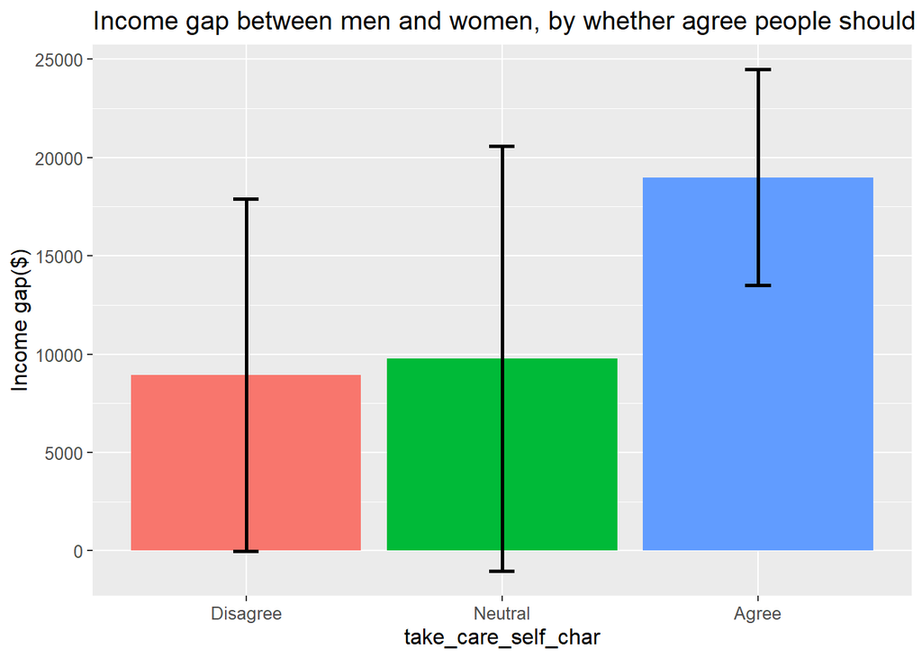

```r
ggplot(data = take_care_self.conf, aes(x = take_care_self_char, y = income.gap,
                            fill = take_care_self_char)) +
  geom_bar(stat = "identity") +
  ylab("Income gap($)") +
  ggtitle("Income gap between men and women, by whether agree people should take care of themselves") +
  guides(fill = FALSE) +
  geom_errorbar(aes(ymax = upper, ymin = lower), width = 0.1, size = 1) +
  theme(text = element_text(size=12))
```

> For respondents who disagree or are neutral about the statement that “those in need have to learn to take care of themselves and not depend on others”, the confidence interval of income gaps between males and females both include an zero, indicating that the income gaps for the two groups are not statistically significant. However, for respondents who agree that people should take care of themselves, the income gap is significant.

### f. Industries

> We believe that different industries have different income structures. Also, some industries have some preferences for a specific sex. So we want to see whether the industry would be a factor that needs to be assessed.

> We first construct plots showing proportion of people in different industries for men and women. Filter out missing values in `income` and `industry` to prevent producing a boxplot of “NA” group.

```r
nlsy.indu <- nlsy %>%
  filter(is.na(income) == FALSE,
         is.na(industry) == FALSE)

nlsy.indu$industry[nlsy.indu$industry >= 170 & nlsy.indu$industry <= 290] <- 'AGRICULTURE'
nlsy.indu$industry[nlsy.indu$industry >= 370 & nlsy.indu$industry <= 490] <- 'MINING'
nlsy.indu$industry[nlsy.indu$industry >= 570 & nlsy.indu$industry <= 690] <- 'UTILITIES'
nlsy.indu$industry[nlsy.indu$industry == 770] <- 'CONSTRUCTION'
nlsy.indu$industry[nlsy.indu$industry >= 1070 & nlsy.indu$industry <= 3990] <- 'MANUFACTURING'
nlsy.indu$industry[nlsy.indu$industry >= 4070 & nlsy.indu$industry <= 4590] <- 'WHOLESALE TRADE'
nlsy.indu$industry[nlsy.indu$industry >= 4670 & nlsy.indu$industry <= 5790] <- 'RETAIL TRADE'
nlsy.indu$industry[nlsy.indu$industry == 5890] <- 'ARTS'
nlsy.indu$industry[nlsy.indu$industry >= 6070 & nlsy.indu$industry <= 6390] <- 'TRANSPORTATION'
nlsy.indu$industry[nlsy.indu$industry >= 6470 & nlsy.indu$industry <= 6780] <- 'INFORMATION'
nlsy.indu$industry[nlsy.indu$industry >= 6870 & nlsy.indu$industry <= 7190] <- 'FINANCE'
nlsy.indu$industry[nlsy.indu$industry >= 7270 & nlsy.indu$industry <= 9290] <- 'SERVICES'
nlsy.indu$industry[nlsy.indu$industry >= 9370 & nlsy.indu$industry <= 9590] <- 'PUBLIC ADMINISTRATION'
nlsy.indu$industry[nlsy.indu$industry >= 9670 & nlsy.indu$industry <= 9890] <- 'MILITARY'
nlsy.indu$industry[nlsy.indu$industry >= 9950 & nlsy.indu$industry <= 9990] <- 'ACS SPECIAL CODES'

industry.table <- table(sex = nlsy.indu$sex, industry = nlsy.indu$industry)
industry.count <- as_tibble(industry.table)
industry.df.count <- industry.count %>%
  group_by(sex) %>%
  mutate(totals = sum(n))

kable(industry.df.count, format = "markdown")
```

| sex | industry | n | totals |
| --- | --- | --- | --- |
| Female | ACS SPECIAL CODES | 101 | 2387 |
| Male | ACS SPECIAL CODES | 102 | 2516 |
| Female | AGRICULTURE | 13 | 2387 |
| Male | AGRICULTURE | 24 | 2516 |
| Female | CONSTRUCTION | 25 | 2387 |
| Male | CONSTRUCTION | 296 | 2516 |
| Female | FINANCE | 118 | 2387 |
| Male | FINANCE | 122 | 2516 |
| Female | MANUFACTURING | 100 | 2387 |
| Male | MANUFACTURING | 267 | 2516 |
| Female | MILITARY | 0 | 2387 |
| Male | MILITARY | 13 | 2516 |
| Female | MINING | 98 | 2387 |
| Male | MINING | 230 | 2516 |
| Female | PUBLIC ADMINISTRATION | 109 | 2387 |
| Male | PUBLIC ADMINISTRATION | 135 | 2516 |
| Female | RETAIL TRADE | 179 | 2387 |
| Male | RETAIL TRADE | 135 | 2516 |
| Female | SERVICES | 1455 | 2387 |
| Male | SERVICES | 914 | 2516 |
| Female | UTILITIES | 189 | 2387 |
| Male | UTILITIES | 278 | 2516 |

```r
industry.toplot <- industry.df.count %>%
  group_by(industry, sex) %>%
  summarize(prop = n/totals,
            lower = prop.test(n, totals)$conf.int[1],
            upper = prop.test(n, totals)$conf.int[2])
kable(industry.toplot, format = "markdown")
```

| industry | sex | prop | lower | upper |
| --- | --- | --- | --- | --- |
| ACS SPECIAL CODES | Female | 0.0423125 | 0.0347554 | 0.0513784 |
| ACS SPECIAL CODES | Male | 0.0405405 | 0.0333283 | 0.0491897 |
| AGRICULTURE | Female | 0.0054462 | 0.0030313 | 0.0095590 |
| AGRICULTURE | Male | 0.0095390 | 0.0062587 | 0.0143914 |
| CONSTRUCTION | Female | 0.0104734 | 0.0069348 | 0.0156642 |
| CONSTRUCTION | Male | 0.1176471 | 0.1054474 | 0.1310308 |
| FINANCE | Female | 0.0494344 | 0.0412474 | 0.0591041 |
| FINANCE | Male | 0.0484897 | 0.0405809 | 0.0578076 |
| MANUFACTURING | Female | 0.0418936 | 0.0343753 | 0.0509222 |
| MANUFACTURING | Male | 0.1061208 | 0.0944923 | 0.1189700 |
| MILITARY | Female | 0.0000000 | 0.0000000 | 0.0020031 |
| MILITARY | Male | 0.0051669 | 0.0028758 | 0.0090701 |
| MINING | Female | 0.0410557 | 0.0336158 | 0.0500091 |
| MINING | Male | 0.0914149 | 0.0805805 | 0.1035170 |
| PUBLIC ADMINISTRATION | Female | 0.0456640 | 0.0378035 | 0.0550209 |
| PUBLIC ADMINISTRATION | Male | 0.0536566 | 0.0453294 | 0.0633753 |
| RETAIL TRADE | Female | 0.0749895 | 0.0648976 | 0.0864742 |
| RETAIL TRADE | Male | 0.0536566 | 0.0453294 | 0.0633753 |
| SERVICES | Female | 0.6095517 | 0.5896088 | 0.6291388 |
| SERVICES | Male | 0.3632750 | 0.3445078 | 0.3824635 |
| UTILITIES | Female | 0.0791789 | 0.0688144 | 0.0909217 |
| UTILITIES | Male | 0.1104928 | 0.0986428 | 0.1235497 |

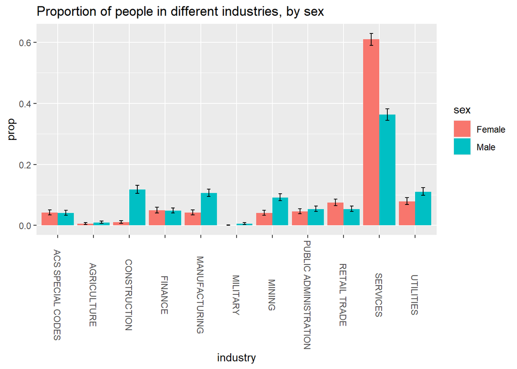

```r
ggplot(industry.toplot, aes(x = industry, y = prop, fill = sex)) +
  geom_bar(position = 'dodge', stat = 'identity') +
  theme(axis.text.x = element_text(angle = - 90, vjust = 0.5)) +
  geom_errorbar(aes(ymin = lower, ymax = upper),
                width = .2,
                position = position_dodge(0.9)) +
  ggtitle("Proportion of people in different industries, by sex")
```

> From the result we can see that some industries have a significantly different propotion of men and women. For example, significantly higher proportion of females work in `services` and `retail trade`. While significantly higher proportion of males work in `construction`, `manufacturing`, `mining`, and `utilities`.

> We want to further investigate the proportion of high income for different industries by sex.

```r
indu.income <- nlsy.indu %>%
  group_by(sex, industry) %>% summarize(total = n(), high_income = sum(income > 50000),
            prop = high_income / total,
            lower = prop.test(high_income, total)$conf.int[1],
            upper = prop.test(high_income, total)$conf.int[2])
kable(indu.income, format = "markdown")
```

| sex | industry | total | high_income | prop | lower | upper |
| --- | --- | --- | --- | --- | --- | --- |
| Female | ACS SPECIAL CODES | 101 | 49 | 0.4851485 | 0.3852872 | 0.5861524 |
| Female | AGRICULTURE | 13 | 3 | 0.2307692 | 0.0616061 | 0.5401511 |
| Female | CONSTRUCTION | 25 | 3 | 0.1200000 | 0.0315159 | 0.3233578 |
| Female | FINANCE | 118 | 49 | 0.4152542 | 0.3264135 | 0.5096892 |
| Female | MANUFACTURING | 100 | 30 | 0.3000000 | 0.2145426 | 0.4010604 |
| Female | MINING | 98 | 27 | 0.2755102 | 0.1923695 | 0.3765401 |
| Female | PUBLIC ADMINISTRATION | 109 | 33 | 0.3027523 | 0.2203536 | 0.3992806 |
| Female | RETAIL TRADE | 179 | 21 | 0.1173184 | 0.0757605 | 0.1758856 |
| Female | SERVICES | 1455 | 362 | 0.2487973 | 0.2269321 | 0.2720058 |
| Female | UTILITIES | 189 | 51 | 0.2698413 | 0.2092079 | 0.3400228 |
| Male | ACS SPECIAL CODES | 102 | 61 | 0.5980392 | 0.4961075 | 0.6924947 |
| Male | AGRICULTURE | 24 | 11 | 0.4583333 | 0.2616528 | 0.6676279 |
| Male | CONSTRUCTION | 296 | 113 | 0.3817568 | 0.3266406 | 0.4399946 |
| Male | FINANCE | 122 | 73 | 0.5983607 | 0.5055443 | 0.6848934 |
| Male | MANUFACTURING | 267 | 115 | 0.4307116 | 0.3708987 | 0.4925515 |
| Male | MILITARY | 13 | 13 | 1.0000000 | 0.7165559 | 1.0000000 |
| Male | MINING | 230 | 95 | 0.4130435 | 0.3492581 | 0.4797826 |
| Male | PUBLIC ADMINISTRATION | 135 | 93 | 0.6888889 | 0.6026379 | 0.7641998 |
| Male | RETAIL TRADE | 135 | 27 | 0.2000000 | 0.1380987 | 0.2793937 |
| Male | SERVICES | 914 | 365 | 0.3993435 | 0.3675398 | 0.4320044 |
| Male | UTILITIES | 278 | 124 | 0.4460432 | 0.3869901 | 0.5066120 |

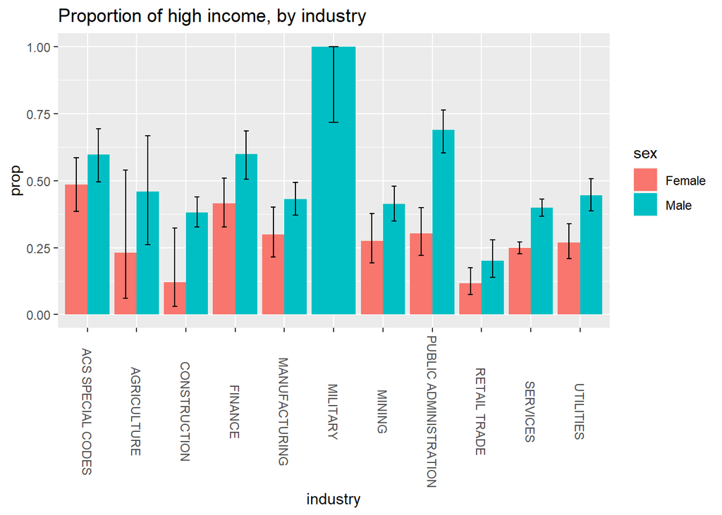

```r
ggplot(indu.income, aes(x = industry, y = prop, fill = sex)) +
  geom_bar(position="dodge", stat="identity") +
  geom_errorbar(aes(ymin = lower, ymax = upper),
                width=.2,
                position=position_dodge(0.9)) +
  theme(axis.text.x = element_text(angle = - 90, vjust = 0.5)) +
  ggtitle("Proportion of high income, by industry")
```

> We can see here that in some certain industries, the difference of high income proportion between men and women are significant, like construction, finance, public administration, services, and utilities. One thing worths noting is that the military industry has no female respondent, so when doing the investigation on income gap, we need to delete the military industry.

> Produce a graph of income gap between men and women across industries to investigate whether industy is one of the factors affecting income gap.

```r
indu.conf <- nlsy.indu %>% filter(industry != "MILITARY") %>%
  group_by(industry) %>%
  summarize(income.gap = mean(income[sex == "Male"], na.rm = TRUE) -
              mean(income[sex == "Female"], na.rm = TRUE),
            lower = betterTTestErrorBars(income, sex)[2],
            upper = betterTTestErrorBars(income, sex)[1],
            is.significant = betterTTestErrorBars(income, sex)[3])
indu.conf <- indu.conf %>%
  mutate(is.significant = recode_factor(is.significant,
                                        "1" = "Yes",
                                        "0" = "No"))
kable(indu.conf, format = "markdown")
```

| industry | income.gap | lower | upper | is.significant |
| --- | --- | --- | --- | --- |
| ACS SPECIAL CODES | 15185.186 | 4008.627 | 26361.75 | Yes |
| AGRICULTURE | 23966.667 | 4820.800 | 43112.53 | Yes |
| CONSTRUCTION | 20915.804 | 11230.006 | 30601.60 | Yes |
| FINANCE | 30185.877 | 16599.340 | 43772.41 | Yes |
| MANUFACTURING | 9268.239 | 1161.304 | 17375.17 | Yes |
| MINING | 14167.503 | 7386.138 | 20948.87 | Yes |
| PUBLIC ADMINISTRATION | 21011.846 | 13194.381 | 28829.31 | Yes |
| RETAIL TRADE | 12586.213 | 4715.910 | 20456.52 | Yes |
| SERVICES | 16641.460 | 12940.706 | 20342.21 | Yes |
| UTILITIES | 13475.277 | 7027.590 | 19922.96 | Yes |

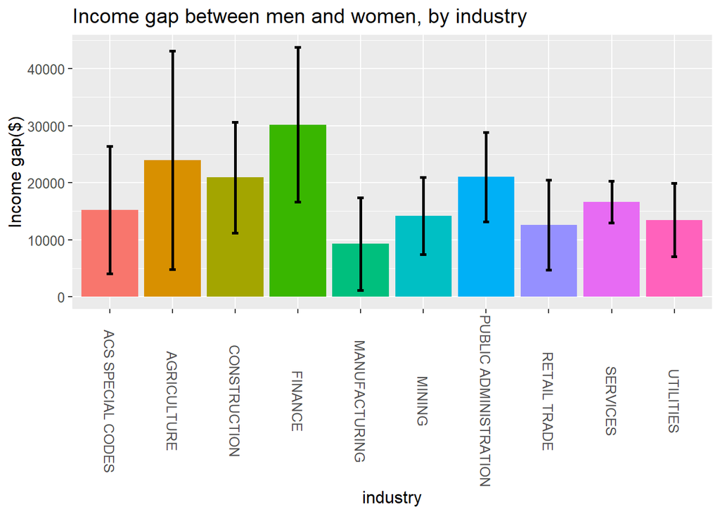

```r
ggplot(data = indu.conf, aes(x = industry, y = income.gap,
                            fill = industry)) +
  geom_bar(stat = "identity") +
  ylab("Income gap($)") +
  ggtitle("Income gap between men and women, by industry") +
  guides(fill = FALSE) +
  geom_errorbar(aes(ymax = upper, ymin = lower), width = 0.1, size = 1) +
  theme(text = element_text(size=12))  +
  theme(axis.text.x = element_text(angle = - 90, vjust = 0.5))
```

> From the result we can see, males have statistically significantly higher income than females in all industries. But the income gap seems not to vary significantly across industries.

### g. Household Composition

> We hypothesized that household composition has a significant influence on the growth of people, and may therefore affect the income. So we want to study the influence of family composition. Similarly, filter out missing values in `income` and `household_composition` to prevent producing a boxplot of “NA” group.

```r
nlsy.hhcurrent <- nlsy %>%
  filter(is.na(income) == FALSE,
         is.na(household_composition) == FALSE)

hhcurrent.income <- nlsy.hhcurrent %>%
  group_by(sex, household_composition ) %>% summarize(total = n(), high_income = sum(income > 50000),
            prop = high_income / total,
            lower = prop.test(high_income, total)$conf.int[1],
            upper = prop.test(high_income, total)$conf.int[2])
kable(hhcurrent.income, format = "markdown")
```

| sex | household_composition | total | high_income | prop | lower | upper |
| --- | --- | --- | --- | --- | --- | --- |
| Female | Both biological parents | 1204 | 397 | 0.3297342 | 0.3033523 | 0.3572160 |
| Female | Two parents, biological mother | 280 | 60 | 0.2142857 | 0.1686423 | 0.2679472 |
| Female | Two parents, biological father | 57 | 10 | 0.1754386 | 0.0917326 | 0.3035768 |
| Female | Biological mother only | 716 | 139 | 0.1941341 | 0.1661706 | 0.2254404 |
| Female | Biological father only | 71 | 9 | 0.1267606 | 0.0631438 | 0.2319853 |
| Female | Adoptive parent(s) | 19 | 7 | 0.3684211 | 0.1723002 | 0.6136729 |
| Female | Foster parent(s) | 7 | 1 | 0.1428571 | 0.0075028 | 0.5799217 |
| Female | No parents, grandparents | 49 | 11 | 0.2244898 | 0.1224894 | 0.3698665 |
| Female | No parents, other relatives | 25 | 5 | 0.2000000 | 0.0760754 | 0.4130071 |
| Female | Anything else | 17 | 3 | 0.1764706 | 0.0467296 | 0.4419559 |
| Male | Both biological parents | 1397 | 730 | 0.5225483 | 0.4959720 | 0.5489993 |
| Male | Two parents, biological mother | 267 | 94 | 0.3520599 | 0.2954611 | 0.4129915 |
| Male | Two parents, biological father | 63 | 21 | 0.3333333 | 0.2226644 | 0.4644230 |
| Male | Biological mother only | 651 | 216 | 0.3317972 | 0.2959641 | 0.3696455 |
| Male | Biological father only | 91 | 28 | 0.3076923 | 0.2174441 | 0.4144002 |
| Male | Adoptive parent(s) | 31 | 12 | 0.3870968 | 0.2241645 | 0.5771290 |
| Male | Foster parent(s) | 14 | 0 | 0.0000000 | 0.0000000 | 0.2676201 |
| Male | No parents, grandparents | 51 | 14 | 0.2745098 | 0.1632668 | 0.4197601 |
| Male | No parents, other relatives | 21 | 3 | 0.1428571 | 0.0376430 | 0.3735664 |
| Male | Anything else | 13 | 3 | 0.2307692 | 0.0616061 | 0.5401511 |

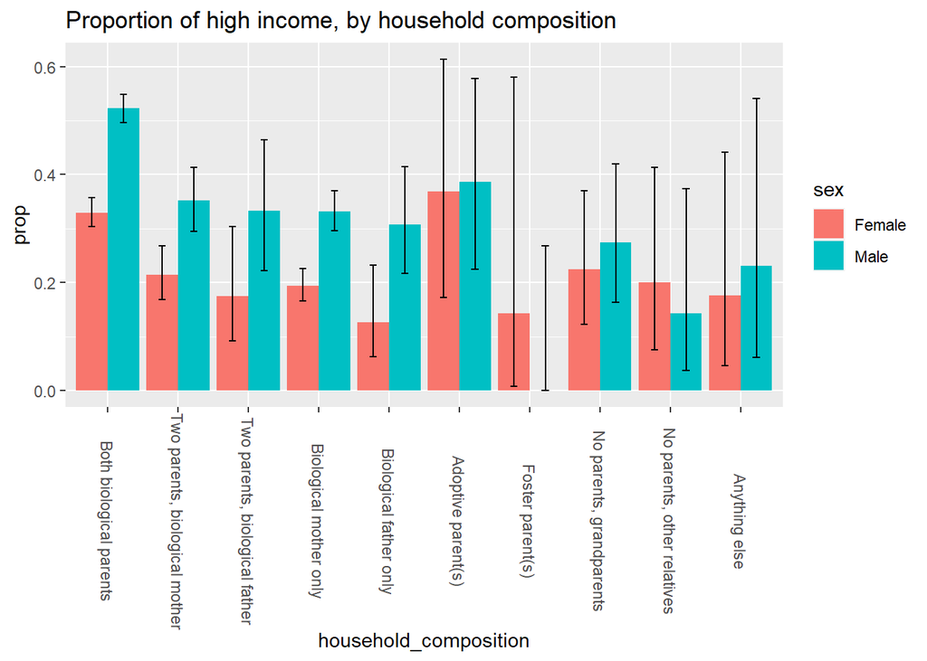

```r
ggplot(hhcurrent.income, aes(x = household_composition , y = prop, fill = sex)) +
  geom_bar(position="dodge", stat="identity") +
  geom_errorbar(aes(ymin = lower, ymax = upper),
                width=.2,
                position=position_dodge(0.9)) +
  theme(axis.text.x = element_text(angle = - 90, vjust = 0.5)) +
  ggtitle("Proportion of high income, by household composition")
```

> Produce a graph of income gap between men and women by household composition to investigate whether household composition is one of the factors affecting income gap.

```r
hhcurrent.conf <- nlsy.hhcurrent %>%
  group_by(household_composition ) %>%
  summarize(income.gap = mean(income[sex == "Male"], na.rm = TRUE) -
              mean(income[sex == "Female"], na.rm = TRUE),
            upper = -t.test(income ~ sex)$conf.int[1],
            lower = -t.test(income ~ sex)$conf.int[2],
            is.significant = as.numeric(t.test(income ~ sex)$p.value < 0.05))
kable(hhcurrent.conf, format = "markdown")
```

| household_composition | income.gap | upper | lower | is.significant |
| --- | --- | --- | --- | --- |
| Both biological parents | 18447.9392 | 21811.22 | 15084.6617 | 1 |
| Two parents, biological mother | 13875.6715 | 19229.56 | 8521.7820 | 1 |
| Two parents, biological father | 13446.6257 | 23515.22 | 3378.0295 | 1 |
| Biological mother only | 11608.0543 | 15102.68 | 8113.4283 | 1 |
| Biological father only | 12503.3631 | 23683.30 | 1323.4222 | 1 |
| Adoptive parent(s) | -358.4448 | 23403.53 | -24120.4245 | 0 |
| Foster parent(s) | -5678.5714 | 20374.17 | -31731.3090 | 0 |
| No parents, grandparents | 16219.9692 | 32917.19 | -477.2537 | 0 |
| No parents, other relatives | 4212.5486 | 15874.92 | -7449.8193 | 0 |
| Anything else | 7963.2398 | 22253.67 | -6327.1929 | 0 |

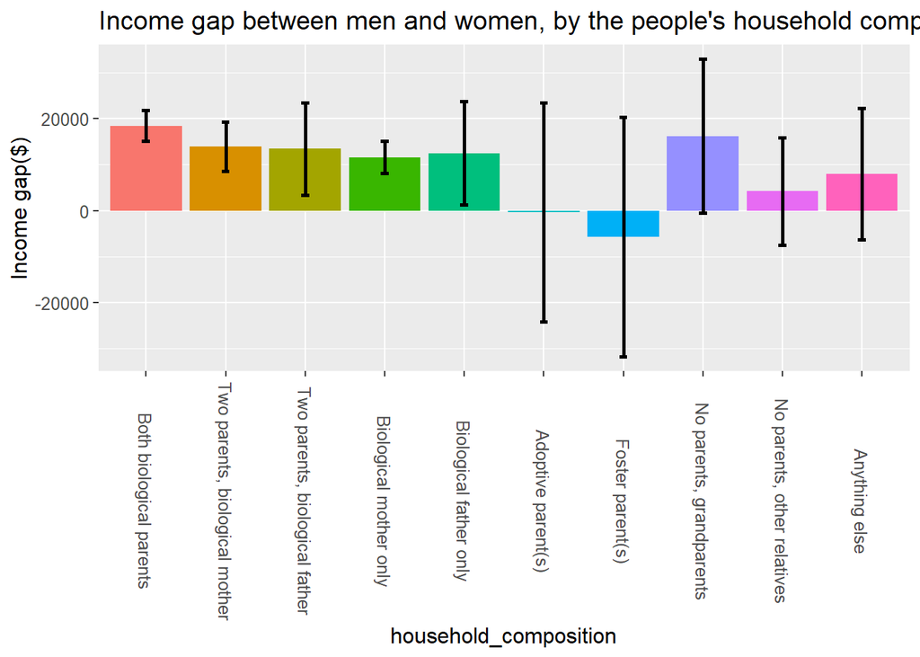

```r
ggplot(data = hhcurrent.conf, aes(x = household_composition, y = income.gap,
                            fill = household_composition)) +
  geom_bar(stat = "identity") +
  ylab("Income gap($)") +
  ggtitle("Income gap between men and women, by the people's household composition") +
  guides(fill = FALSE) +
  geom_errorbar(aes(ymax = upper, ymin = lower), width = 0.1, size = 1) +
  theme(axis.text.x = element_text(angle = - 90, vjust = 0.5)) +
  theme(text = element_text(size=12))
```

> From the result we can see, for household composition of `both biological parents`, `two parents, biological mother`, `two parents, biological father`, `biological mother only`, and `biological father only`, males have significantly higher income than females. But the income gaps don’t seem to vary across different households.

## Part II: Linear Model

### a. Data Processing

> To ensure the sample sizes of different columns and different regression models are the same, we filter out missing values of all the variables discussed above.

```r
nlsy.copy5 <- nlsy.indu %>% filter(is.na(income) == FALSE,
                              is.na(highest_degree) == FALSE,
                              is.na(marital_status) == FALSE,
                              is.na(children_num) == FALSE,
                              is.na(disorganized_char) == FALSE,
                              is.na(industry) == FALSE,
                              is.na(household_composition) == FALSE)

nlsy.copy5 <- nlsy.copy5 %>% mutate(children = recode_factor(children_num,
                                                "0" = "No",
                                                "1" = "Yes",
                                                "2" = "Yes",
                                                "3" = "Yes",
                                                "4" = "Yes",
                                                "5" = "Yes",
                                                "6" = "Yes",
                                                "7" = "Yes",
                                                "8" = "Yes",
                                                "9" = "Yes",
                                                "12" = "Yes"))
```

### b. Regression without interaction terms

> In this section, we are going to run regressions on the variables discussed above. Since the relationship between `help_less_fortunate` and `take_care_self` are not statistically significantly associated with `income`, we are not goint to add those two variables in the regression model. Also, if holding `highest_degree` constant, the relationship between `trustful` and `income` became insignificant. Therefore, we will only include `disorganized` among personalities and values variables.

```r
nlsy.lm <- lm(income ~ sex + highest_degree + marital_status + children + disorganized_char + industry + household_composition, data = nlsy.copy5)

summary(nlsy.lm)
```

```
##
## Call:
## lm(formula = income ~ sex + highest_degree + marital_status +
##     children + disorganized_char + industry + household_composition,
##     data = nlsy.copy5)
##
## Residuals:
##     Min      1Q  Median      3Q     Max
## -141990  -16182   -2746   10782  185055
##
## Coefficients:
##                                                     Estimate Std. Error t value
## (Intercept)                                          21449.1     5091.9   4.212
## sexMale                                              20345.2     1603.6  12.687
## highest_degreeGED                                     2547.2     3139.9   0.811
## highest_degreeHigh School                             7640.5     2655.4   2.877
## highest_degreeAssociate/Junior                       17625.9     3522.8   5.003
## highest_degreeBachelor's                             29983.0     3057.2   9.807
## highest_degreeMaster's                               39030.9     4371.7   8.928
## highest_degreePhD                                    58054.1    12942.4   4.486
## highest_degreeProfessional                          119513.3     7374.8  16.206
## marital_statusMarried                                 7682.9     1743.8   4.406
## marital_statusSeparated                                503.9     4141.8   0.122
## marital_statusDivorced                                6592.4     2465.7   2.674
## marital_statusWidowed                                -8260.6    14283.4  -0.578
## childrenYes                                           8506.6     2458.1   3.461
## disorganized_charNeutral                              1238.2     2319.3   0.534
## disorganized_charOrganized                            4170.9     2104.8   1.982
## industryAGRICULTURE                                 -12448.6     9203.3  -1.353
## industryCONSTRUCTION                                -11223.9     4318.8  -2.599
## industryFINANCE                                      -9013.4     4697.1  -1.919
## industryMANUFACTURING                               -11059.6     4213.5  -2.625
## industryMILITARY                                     -3857.8    16736.6  -0.230
## industryMINING                                      -12923.5     4295.8  -3.008
## industryPUBLIC ADMINISTRATION                        -6748.3     4492.5  -1.502
## industryRETAIL TRADE                                -25614.9     4425.4  -5.788
## industrySERVICES                                    -15833.3     3468.7  -4.565
## industryUTILITIES                                   -11283.6     4041.1  -2.792
## household_compositionTwo parents, biological mother  -1458.0     2378.2  -0.613
## household_compositionTwo parents, biological father  -2207.5     4318.2  -0.511
```

[output cut: 34 more lines]

```
## household_compositionTwo parents, biological mother 0.539904
## household_compositionTwo parents, biological father 0.609277
## household_compositionBiological mother only         0.062984 .
## household_compositionBiological father only         0.256002
## household_compositionAdoptive parent(s)             0.334731
## household_compositionFoster parent(s)               0.339134
## household_compositionNo parents, grandparents       0.611800
## household_compositionNo parents, other relatives    0.219224
## household_compositionAnything else                  0.375349
## ---
## Signif. codes:  0 '***' 0.001 '**' 0.01 '*' 0.05 '.' 0.1 ' ' 1
##
## Residual standard error: 28220 on 1579 degrees of freedom
## Multiple R-squared:  0.3656, Adjusted R-squared:  0.3519
## F-statistic: 26.76 on 34 and 1579 DF,  p-value: < 2.2e-16
```

```r
kable(coef(summary(nlsy.lm)), digits = c(0, 0, 2, 4))
```

|  | Estimate | Std. Error | t value | Pr(>\|t\|) |
| --- | --- | --- | --- | --- |
| (Intercept) | 21449 | 5092 | 4.21 | 0.0000 |
| sexMale | 20345 | 1604 | 12.69 | 0.0000 |
| highest_degreeGED | 2547 | 3140 | 0.81 | 0.4174 |
| highest_degreeHigh School | 7641 | 2655 | 2.88 | 0.0041 |
| highest_degreeAssociate/Junior | 17626 | 3523 | 5.00 | 0.0000 |
| highest_degreeBachelor’s | 29983 | 3057 | 9.81 | 0.0000 |
| highest_degreeMaster’s | 39031 | 4372 | 8.93 | 0.0000 |
| highest_degreePhD | 58054 | 12942 | 4.49 | 0.0000 |
| highest_degreeProfessional | 119513 | 7375 | 16.21 | 0.0000 |
| marital_statusMarried | 7683 | 1744 | 4.41 | 0.0000 |
| marital_statusSeparated | 504 | 4142 | 0.12 | 0.9032 |
| marital_statusDivorced | 6592 | 2466 | 2.67 | 0.0076 |
| marital_statusWidowed | -8261 | 14283 | -0.58 | 0.5631 |
| childrenYes | 8507 | 2458 | 3.46 | 0.0006 |
| disorganized_charNeutral | 1238 | 2319 | 0.53 | 0.5935 |
| disorganized_charOrganized | 4171 | 2105 | 1.98 | 0.0477 |
| industryAGRICULTURE | -12449 | 9203 | -1.35 | 0.1764 |
| industryCONSTRUCTION | -11224 | 4319 | -2.60 | 0.0094 |
| industryFINANCE | -9013 | 4697 | -1.92 | 0.0552 |
| industryMANUFACTURING | -11060 | 4214 | -2.62 | 0.0088 |
| industryMILITARY | -3858 | 16737 | -0.23 | 0.8177 |
| industryMINING | -12924 | 4296 | -3.01 | 0.0027 |
| industryPUBLIC ADMINISTRATION | -6748 | 4492 | -1.50 | 0.1333 |
| industryRETAIL TRADE | -25615 | 4425 | -5.79 | 0.0000 |
| industrySERVICES | -15833 | 3469 | -4.56 | 0.0000 |
| industryUTILITIES | -11284 | 4041 | -2.79 | 0.0053 |
| household_compositionTwo parents, biological mother | -1458 | 2378 | -0.61 | 0.5399 |
| household_compositionTwo parents, biological father | -2208 | 4318 | -0.51 | 0.6093 |
| household_compositionBiological mother only | -3213 | 1727 | -1.86 | 0.0630 |
| household_compositionBiological father only | -4970 | 4374 | -1.14 | 0.2560 |
| household_compositionAdoptive parent(s) | -8334 | 8637 | -0.96 | 0.3347 |
| household_compositionFoster parent(s) | -9144 | 9563 | -0.96 | 0.3391 |
| household_compositionNo parents, grandparents | 2664 | 5247 | 0.51 | 0.6118 |
| household_compositionNo parents, other relatives | -9104 | 7407 | -1.23 | 0.2192 |
| household_compositionAnything else | -10302 | 11618 | -0.89 | 0.3753 |

> From the first regression model, we see that the coefficients for `household_composition` became not statistically significant. Hence, we are going to remove this variable, and see whether that would significantly affect the model performance.

```r
anova(update(nlsy.lm, . ~ . - household_composition), nlsy.lm)
```

```
## Analysis of Variance Table
##
## Model 1: income ~ sex + highest_degree + marital_status + children + disorganized_char +
##     industry
## Model 2: income ~ sex + highest_degree + marital_status + children + disorganized_char +
##     industry + household_composition
##   Res.Df        RSS Df  Sum of Sq      F Pr(>F)
## 1   1588 1.2641e+12
## 2   1579 1.2579e+12  9 6202606530 0.8651  0.556
```

> From the anova test, we see that `household_composition` is not a statistically significant factor in the model. Therefore, we are going to remove this variable.

> From the first model, we also see that some coefficients for the variable `industry` are not statistically significant. So next, we are going to examine whether removing `industry` will significantly affect the model.

```r
anova(update(nlsy.lm, . ~ . - household_composition),
      update(nlsy.lm, . ~ . - household_composition - industry))
```

```
## Analysis of Variance Table
##
## Model 1: income ~ sex + highest_degree + marital_status + children + disorganized_char +
##     industry
## Model 2: income ~ sex + highest_degree + marital_status + children + disorganized_char
##   Res.Df        RSS  Df   Sum of Sq      F    Pr(>F)
## 1   1588 1.2641e+12
## 2   1598 1.3033e+12 -10 -3.9206e+10 4.9253 4.768e-07 ***
## ---
## Signif. codes:  0 '***' 0.001 '**' 0.01 '*' 0.05 '.' 0.1 ' ' 1
```

> `industry` is a statistically significant factor in the model. It is unlikely that the improvement in fit when the add of the `industry` variable is simply due to random fluctuations in the data. Thus it is important to consider `industry` when modeling `income`.

> From the first model, we see that the coefficient for `disorganized` is significant at the 0.05 level. But we will examine whether `disorganized` is a significant factor in the model.

```r
anova(update(nlsy.lm, . ~ . - household_composition - disorganized_char), nlsy.lm)
```

```
## Analysis of Variance Table
##
## Model 1: income ~ sex + highest_degree + marital_status + children + industry
## Model 2: income ~ sex + highest_degree + marital_status + children + disorganized_char +
##     industry + household_composition
##   Res.Df        RSS Df  Sum of Sq      F Pr(>F)
## 1   1590 1.2688e+12
## 2   1579 1.2579e+12 11 1.0906e+10 1.2446 0.2518
```

> `disorganized` is not a statistically significant factor in the model. Therefore, we are going to remove this variable.

> Next, we will examine `children`.

```r
anova(update(nlsy.lm, . ~ . - household_composition - disorganized_char),
      update(nlsy.lm, . ~ . - household_composition - disorganized_char - children))
```

```
## Analysis of Variance Table
##
## Model 1: income ~ sex + highest_degree + marital_status + children + industry
## Model 2: income ~ sex + highest_degree + marital_status + industry
##   Res.Df        RSS Df   Sum of Sq      F    Pr(>F)
## 1   1590 1.2688e+12
## 2   1591 1.2790e+12 -1 -1.0258e+10 12.855 0.0003468 ***
## ---
## Signif. codes:  0 '***' 0.001 '**' 0.01 '*' 0.05 '.' 0.1 ' ' 1
```

> `children` is a statistically significant factor in the model.It is important to consider `children` when modeling `income`.

> Next, we will examine `marital_status`.

```r
anova(update(nlsy.lm, . ~ . - household_composition - disorganized_char),
      update(nlsy.lm, . ~ . - household_composition - disorganized_char - marital_status))
```

```
## Analysis of Variance Table
##
## Model 1: income ~ sex + highest_degree + marital_status + children + industry
## Model 2: income ~ sex + highest_degree + children + industry
##   Res.Df        RSS Df   Sum of Sq      F    Pr(>F)
## 1   1590 1.2688e+12
## 2   1594 1.2895e+12 -4 -2.0727e+10 6.4938 3.502e-05 ***
## ---
## Signif. codes:  0 '***' 0.001 '**' 0.01 '*' 0.05 '.' 0.1 ' ' 1
```

> `marital_status` is a statistically significant factor in the model.It is important to consider `marital_status` when modeling `income`.

> Next, we will examine `highest_degree`.

```r
anova(update(nlsy.lm, . ~ . - household_composition - disorganized_char),
      update(nlsy.lm, . ~ . - household_composition - disorganized_char - highest_degree))
```

```
## Analysis of Variance Table
##
## Model 1: income ~ sex + highest_degree + marital_status + children + industry
## Model 2: income ~ sex + marital_status + children + industry
##   Res.Df        RSS Df  Sum of Sq      F    Pr(>F)
## 1   1590 1.2688e+12
## 2   1597 1.6431e+12 -7 -3.743e+11 67.009 < 2.2e-16 ***
## ---
## Signif. codes:  0 '***' 0.001 '**' 0.01 '*' 0.05 '.' 0.1 ' ' 1
```

> `highest_degree` is a statistically significant factor in the model. It is important to consider `highest_degree` when modeling `income`.

> Now that we’ve examined all the variables’ influence on the model. We conclude the second linear model as the following:

```r
nlsy.lm.select <- lm(income ~ sex + highest_degree + marital_status + children + industry, data = nlsy.copy5)

summary(nlsy.lm.select)
```

```
##
## Call:
## lm(formula = income ~ sex + highest_degree + marital_status +
##     children + industry, data = nlsy.copy5)
##
## Residuals:
##     Min      1Q  Median      3Q     Max
## -140843  -16099   -3258   10838  187881
##
## Coefficients:
##                                Estimate Std. Error t value Pr(>|t|)
## (Intercept)                     21078.6     4647.8   4.535 6.19e-06 ***
## sexMale                         20415.2     1594.8  12.801  < 2e-16 ***
## highest_degreeGED                2808.0     3115.1   0.901 0.367509
## highest_degreeHigh School        8583.2     2629.4   3.264 0.001121 **
## highest_degreeAssociate/Junior  18674.5     3503.2   5.331 1.12e-07 ***
## highest_degreeBachelor's        31422.7     3009.5  10.441  < 2e-16 ***
## highest_degreeMaster's          40870.1     4334.8   9.428  < 2e-16 ***
## highest_degreePhD               60405.9    12926.1   4.673 3.22e-06 ***
## highest_degreeProfessional     122049.3     7337.1  16.635  < 2e-16 ***
## marital_statusMarried            8241.2     1714.4   4.807 1.68e-06 ***
## marital_statusSeparated           757.8     4133.5   0.183 0.854564
## marital_statusDivorced           6665.0     2461.3   2.708 0.006842 **
## marital_statusWidowed           -8253.1    14278.6  -0.578 0.563343
## childrenYes                      8798.7     2454.1   3.585 0.000347 ***
## industryAGRICULTURE            -12298.2     9164.7  -1.342 0.179818
## industryCONSTRUCTION           -11430.8     4299.9  -2.658 0.007931 **
## industryFINANCE                 -9056.1     4689.5  -1.931 0.053644 .
## industryMANUFACTURING          -11126.9     4205.8  -2.646 0.008235 **
## industryMILITARY                -3093.8    16684.0  -0.185 0.852912
## industryMINING                 -12243.9     4285.2  -2.857 0.004329 **
## industryPUBLIC ADMINISTRATION   -6514.4     4470.8  -1.457 0.145292
## industryRETAIL TRADE           -25463.8     4399.4  -5.788 8.56e-09 ***
## industrySERVICES               -15824.7     3460.6  -4.573 5.18e-06 ***
## industryUTILITIES              -10872.6     4025.5  -2.701 0.006988 **
## ---
## Signif. codes:  0 '***' 0.001 '**' 0.01 '*' 0.05 '.' 0.1 ' ' 1
##
## Residual standard error: 28250 on 1590 degrees of freedom
## Multiple R-squared:  0.3601, Adjusted R-squared:  0.3508
## F-statistic:  38.9 on 23 and 1590 DF,  p-value: < 2.2e-16
```

```r
kable(coef(summary(nlsy.lm.select)), digits = c(0, 0, 2, 4))
```

|  | Estimate | Std. Error | t value | Pr(>\|t\|) |
| --- | --- | --- | --- | --- |
| (Intercept) | 21079 | 4648 | 4.54 | 0.0000 |
| sexMale | 20415 | 1595 | 12.80 | 0.0000 |
| highest_degreeGED | 2808 | 3115 | 0.90 | 0.3675 |
| highest_degreeHigh School | 8583 | 2629 | 3.26 | 0.0011 |
| highest_degreeAssociate/Junior | 18674 | 3503 | 5.33 | 0.0000 |
| highest_degreeBachelor’s | 31423 | 3010 | 10.44 | 0.0000 |
| highest_degreeMaster’s | 40870 | 4335 | 9.43 | 0.0000 |
| highest_degreePhD | 60406 | 12926 | 4.67 | 0.0000 |
| highest_degreeProfessional | 122049 | 7337 | 16.63 | 0.0000 |
| marital_statusMarried | 8241 | 1714 | 4.81 | 0.0000 |
| marital_statusSeparated | 758 | 4134 | 0.18 | 0.8546 |
| marital_statusDivorced | 6665 | 2461 | 2.71 | 0.0068 |
| marital_statusWidowed | -8253 | 14279 | -0.58 | 0.5633 |
| childrenYes | 8799 | 2454 | 3.59 | 0.0003 |
| industryAGRICULTURE | -12298 | 9165 | -1.34 | 0.1798 |
| industryCONSTRUCTION | -11431 | 4300 | -2.66 | 0.0079 |
| industryFINANCE | -9056 | 4689 | -1.93 | 0.0536 |
| industryMANUFACTURING | -11127 | 4206 | -2.65 | 0.0082 |
| industryMILITARY | -3094 | 16684 | -0.19 | 0.8529 |
| industryMINING | -12244 | 4285 | -2.86 | 0.0043 |
| industryPUBLIC ADMINISTRATION | -6514 | 4471 | -1.46 | 0.1453 |
| industryRETAIL TRADE | -25464 | 4399 | -5.79 | 0.0000 |
| industrySERVICES | -15825 | 3461 | -4.57 | 0.0000 |
| industryUTILITIES | -10873 | 4025 | -2.70 | 0.0070 |

### c. Regression with interaction terms

> In this section, we will add interaction terms to the linear model. As the previous analysis shows, the income gap between males and females is significantly larger for respondents who have children. So we will first examine the interaction between `sex` and `children`.

```r
nlsy.lm.child.interact <- update(nlsy.lm.select, . ~ . + sex * children)
summary(nlsy.lm.child.interact)
```

```
##
## Call:
## lm(formula = income ~ sex + highest_degree + marital_status +
##     children + industry + sex:children, data = nlsy.copy5)
##
## Residuals:
##     Min      1Q  Median      3Q     Max
## -140635  -16100   -2941   10804  187244
##
## Coefficients:
##                                Estimate Std. Error t value Pr(>|t|)
## (Intercept)                     32431.8     7296.7   4.445 9.41e-06 ***
## sexMale                          7540.8     6578.7   1.146 0.251866
## highest_degreeGED                2799.0     3112.1   0.899 0.368580
## highest_degreeHigh School        8743.9     2628.1   3.327 0.000898 ***
## highest_degreeAssociate/Junior  18810.8     3500.4   5.374 8.85e-08 ***
## highest_degreeBachelor's        31602.9     3008.0  10.506  < 2e-16 ***
## highest_degreeMaster's          41111.1     4332.3   9.489  < 2e-16 ***
## highest_degreePhD               60581.2    12913.9   4.691 2.95e-06 ***
## highest_degreeProfessional     122319.0     7331.2  16.685  < 2e-16 ***
## marital_statusMarried            8067.4     1714.9   4.704 2.77e-06 ***
## marital_statusSeparated           653.5     4129.9   0.158 0.874282
## marital_statusDivorced           6570.5     2459.3   2.672 0.007625 **
## marital_statusWidowed           -8117.6    14265.0  -0.569 0.569400
## childrenYes                     -2884.1     6289.6  -0.459 0.646614
## industryAGRICULTURE            -12213.0     9156.0  -1.334 0.182434
## industryCONSTRUCTION           -11456.7     4295.8  -2.667 0.007732 **
## industryFINANCE                 -9073.1     4685.0  -1.937 0.052967 .
## industryMANUFACTURING          -11425.2     4204.3  -2.717 0.006650 **
## industryMILITARY                -3500.1    16669.1  -0.210 0.833715
## industryMINING                 -12323.4     4281.3  -2.878 0.004050 **
## industryPUBLIC ADMINISTRATION   -6506.5     4466.5  -1.457 0.145393
## industryRETAIL TRADE           -25408.8     4395.3  -5.781 8.92e-09 ***
## industrySERVICES               -15799.3     3457.2  -4.570 5.26e-06 ***
## industryUTILITIES              -10817.1     4021.7  -2.690 0.007227 **
## sexMale:childrenYes             13625.1     6755.0   2.017 0.043859 *
## ---
## Signif. codes:  0 '***' 0.001 '**' 0.01 '*' 0.05 '.' 0.1 ' ' 1
##
## Residual standard error: 28220 on 1589 degrees of freedom
## Multiple R-squared:  0.3617, Adjusted R-squared:  0.3521
## F-statistic: 37.52 on 24 and 1589 DF,  p-value: < 2.2e-16
```

```r
kable(coef(summary(nlsy.lm.child.interact)), digits = c(0, 0, 2, 4))
```

|  | Estimate | Std. Error | t value | Pr(>\|t\|) |
| --- | --- | --- | --- | --- |
| (Intercept) | 32432 | 7297 | 4.44 | 0.0000 |
| sexMale | 7541 | 6579 | 1.15 | 0.2519 |
| highest_degreeGED | 2799 | 3112 | 0.90 | 0.3686 |
| highest_degreeHigh School | 8744 | 2628 | 3.33 | 0.0009 |
| highest_degreeAssociate/Junior | 18811 | 3500 | 5.37 | 0.0000 |
| highest_degreeBachelor’s | 31603 | 3008 | 10.51 | 0.0000 |
| highest_degreeMaster’s | 41111 | 4332 | 9.49 | 0.0000 |
| highest_degreePhD | 60581 | 12914 | 4.69 | 0.0000 |
| highest_degreeProfessional | 122319 | 7331 | 16.68 | 0.0000 |
| marital_statusMarried | 8067 | 1715 | 4.70 | 0.0000 |
| marital_statusSeparated | 654 | 4130 | 0.16 | 0.8743 |
| marital_statusDivorced | 6571 | 2459 | 2.67 | 0.0076 |
| marital_statusWidowed | -8118 | 14265 | -0.57 | 0.5694 |
| childrenYes | -2884 | 6290 | -0.46 | 0.6466 |
| industryAGRICULTURE | -12213 | 9156 | -1.33 | 0.1824 |
| industryCONSTRUCTION | -11457 | 4296 | -2.67 | 0.0077 |
| industryFINANCE | -9073 | 4685 | -1.94 | 0.0530 |
| industryMANUFACTURING | -11425 | 4204 | -2.72 | 0.0066 |
| industryMILITARY | -3500 | 16669 | -0.21 | 0.8337 |
| industryMINING | -12323 | 4281 | -2.88 | 0.0040 |
| industryPUBLIC ADMINISTRATION | -6506 | 4467 | -1.46 | 0.1454 |
| industryRETAIL TRADE | -25409 | 4395 | -5.78 | 0.0000 |
| industrySERVICES | -15799 | 3457 | -4.57 | 0.0000 |
| industryUTILITIES | -10817 | 4022 | -2.69 | 0.0072 |
| sexMale:childrenYes | 13625 | 6755 | 2.02 | 0.0439 |

> We see that when the interaction term between `sex` and `children` is added, the coefficients of either `sex` or `children` become not significant, but the coefficient of the interaction of the two factors is statistically significant. The income gap between males and females increases $13625.1 for respondents who have children.

> Next, we will examine whether the interaction term between `sex` and `children` is a significant factor in the linear model.

```r
anova(nlsy.lm, nlsy.lm.child.interact)
```

```
## Analysis of Variance Table
##
## Model 1: income ~ sex + highest_degree + marital_status + children + disorganized_char +
##     industry + household_composition
## Model 2: income ~ sex + highest_degree + marital_status + children + industry +
##     sex:children
##   Res.Df        RSS  Df   Sum of Sq      F Pr(>F)
## 1   1579 1.2579e+12
## 2   1589 1.2655e+12 -10 -7665465866 0.9623 0.4747
```

> As the previous analysis shows, the income gap between males and females is significantly larger among married respondents than never-married or divorced respondents. So next we will examine the interaction effect of `sex` and `marital_status`.

```r
nlsy.lm.mari.interact <- update(nlsy.lm.select, . ~ . + sex * marital_status)
summary(nlsy.lm.mari.interact)
```

```
##
## Call:
## lm(formula = income ~ sex + highest_degree + marital_status +
##     children + industry + sex:marital_status, data = nlsy.copy5)
##
## Residuals:
##     Min      1Q  Median      3Q     Max
## -138046  -16352   -3240   10341  192376
##
## Coefficients: (1 not defined because of singularities)
##                                 Estimate Std. Error t value Pr(>|t|)
## (Intercept)                      26270.4     4836.1   5.432 6.43e-08 ***
## sexMale                          13105.9     2771.1   4.730 2.45e-06 ***
## highest_degreeGED                 3205.4     3103.8   1.033 0.301896
## highest_degreeHigh School         8741.1     2617.6   3.339 0.000859 ***
## highest_degreeAssociate/Junior   18525.2     3490.2   5.308 1.27e-07 ***
## highest_degreeBachelor's         31853.0     2996.8  10.629  < 2e-16 ***
## highest_degreeMaster's           41348.4     4315.7   9.581  < 2e-16 ***
## highest_degreePhD                61394.3    12865.6   4.772 1.99e-06 ***
## highest_degreeProfessional      122046.8     7301.9  16.714  < 2e-16 ***
## marital_statusMarried             2769.2     2236.7   1.238 0.215875
## marital_statusSeparated           3259.4     5787.9   0.563 0.573417
## marital_statusDivorced            6047.2     3198.7   1.891 0.058871 .
## marital_statusWidowed           -11014.8    14239.7  -0.774 0.439328
## childrenYes                       6292.3     2516.6   2.500 0.012508 *
## industryAGRICULTURE             -12972.8     9122.3  -1.422 0.155195
## industryCONSTRUCTION            -10937.2     4284.1  -2.553 0.010774 *
## industryFINANCE                  -9483.3     4668.0  -2.032 0.042364 *
## industryMANUFACTURING           -11044.6     4187.5  -2.638 0.008433 **
## industryMILITARY                 -5571.9    16613.3  -0.335 0.737375
## industryMINING                  -12731.3     4267.0  -2.984 0.002891 **
## industryPUBLIC ADMINISTRATION    -7478.7     4455.3  -1.679 0.093423 .
## industryRETAIL TRADE            -25720.4     4380.8  -5.871 5.26e-09 ***
## industrySERVICES                -15833.0     3444.9  -4.596 4.65e-06 ***
## industryUTILITIES               -10902.3     4007.5  -2.720 0.006590 **
## sexMale:marital_statusMarried    12427.7     3277.8   3.791 0.000155 ***
## sexMale:marital_statusSeparated  -4072.3     8236.0  -0.494 0.621052
## sexMale:marital_statusDivorced     870.6     4928.4   0.177 0.859806
## sexMale:marital_statusWidowed         NA         NA      NA       NA
## ---
## Signif. codes:  0 '***' 0.001 '**' 0.01 '*' 0.05 '.' 0.1 ' ' 1
##
## Residual standard error: 28110 on 1587 degrees of freedom
## Multiple R-squared:  0.3675, Adjusted R-squared:  0.3571
## F-statistic: 35.46 on 26 and 1587 DF,  p-value: < 2.2e-16
```

```r
kable(coef(summary(nlsy.lm.mari.interact)), digits = c(0, 0, 2, 4))
```

|  | Estimate | Std. Error | t value | Pr(>\|t\|) |
| --- | --- | --- | --- | --- |
| (Intercept) | 26270 | 4836 | 5.43 | 0.0000 |
| sexMale | 13106 | 2771 | 4.73 | 0.0000 |
| highest_degreeGED | 3205 | 3104 | 1.03 | 0.3019 |
| highest_degreeHigh School | 8741 | 2618 | 3.34 | 0.0009 |
| highest_degreeAssociate/Junior | 18525 | 3490 | 5.31 | 0.0000 |
| highest_degreeBachelor’s | 31853 | 2997 | 10.63 | 0.0000 |
| highest_degreeMaster’s | 41348 | 4316 | 9.58 | 0.0000 |
| highest_degreePhD | 61394 | 12866 | 4.77 | 0.0000 |
| highest_degreeProfessional | 122047 | 7302 | 16.71 | 0.0000 |
| marital_statusMarried | 2769 | 2237 | 1.24 | 0.2159 |
| marital_statusSeparated | 3259 | 5788 | 0.56 | 0.5734 |
| marital_statusDivorced | 6047 | 3199 | 1.89 | 0.0589 |
| marital_statusWidowed | -11015 | 14240 | -0.77 | 0.4393 |
| childrenYes | 6292 | 2517 | 2.50 | 0.0125 |
| industryAGRICULTURE | -12973 | 9122 | -1.42 | 0.1552 |
| industryCONSTRUCTION | -10937 | 4284 | -2.55 | 0.0108 |
| industryFINANCE | -9483 | 4668 | -2.03 | 0.0424 |
| industryMANUFACTURING | -11045 | 4187 | -2.64 | 0.0084 |
| industryMILITARY | -5572 | 16613 | -0.34 | 0.7374 |
| industryMINING | -12731 | 4267 | -2.98 | 0.0029 |
| industryPUBLIC ADMINISTRATION | -7479 | 4455 | -1.68 | 0.0934 |
| industryRETAIL TRADE | -25720 | 4381 | -5.87 | 0.0000 |
| industrySERVICES | -15833 | 3445 | -4.60 | 0.0000 |
| industryUTILITIES | -10902 | 4008 | -2.72 | 0.0066 |
| sexMale:marital_statusMarried | 12428 | 3278 | 3.79 | 0.0002 |
| sexMale:marital_statusSeparated | -4072 | 8236 | -0.49 | 0.6211 |
| sexMale:marital_statusDivorced | 871 | 4928 | 0.18 | 0.8598 |

> We see that the interaction between `sex` and `married` is statistically significant. The income gap between males and females increases $12427.7 for married respondents than never-married respondents.

> As the coefficients for other interaction terms are not statistically significant, we are going to see whether the interaction between `sex` and `marrital_status` will significantly affect the model.

```r
anova(nlsy.lm.select, nlsy.lm.mari.interact)
```

```
## Analysis of Variance Table
##
## Model 1: income ~ sex + highest_degree + marital_status + children + industry
## Model 2: income ~ sex + highest_degree + marital_status + children + industry +
##     sex:marital_status
##   Res.Df        RSS Df  Sum of Sq      F    Pr(>F)
## 1   1590 1.2688e+12
## 2   1587 1.2541e+12  3 1.4634e+10 6.1727 0.0003609 ***
## ---
## Signif. codes:  0 '***' 0.001 '**' 0.01 '*' 0.05 '.' 0.1 ' ' 1
```

> The interaction between `sex` and `marrital_status` is a statistically significant factor in the model. It is important to consider this interaction term.

> From the previous analysis, we see that the income gap between males and females is statistically significantly higher for respondents with a Bachelor’s degree than respondents with Associate/Junior degree or High School degree. Therefore, in the next section, we will examine the interaction term between `sex` and `highest_degree`.

```r
nlsy.lm.edu.interact <- update(nlsy.lm.select, . ~ . + sex * highest_degree)
summary(nlsy.lm.edu.interact)
```

```
##
## Call:
## lm(formula = income ~ sex + highest_degree + marital_status +
##     children + industry + sex:highest_degree, data = nlsy.copy5)
##
## Residuals:
##     Min      1Q  Median      3Q     Max
## -126037  -15639   -3260   10390  189036
##
## Coefficients:
##                                        Estimate Std. Error t value Pr(>|t|)
## (Intercept)                               23446       5250   4.466 8.54e-06 ***
## sexMale                                   16702       4916   3.397 0.000697 ***
## highest_degreeGED                          5427       4582   1.184 0.236433
## highest_degreeHigh School                  8125       3732   2.177 0.029630 *
## highest_degreeAssociate/Junior            19127       4741   4.034 5.74e-05 ***
## highest_degreeBachelor's                  26920       4098   6.568 6.89e-11 ***
## highest_degreeMaster's                    33210       5573   5.959 3.12e-09 ***
## highest_degreePhD                         56230      16645   3.378 0.000747 ***
## highest_degreeProfessional               106024       9570  11.079  < 2e-16 ***
## marital_statusMarried                      8314       1707   4.869 1.23e-06 ***
## marital_statusSeparated                    1219       4120   0.296 0.767441
## marital_statusDivorced                     6571       2449   2.683 0.007376 **
## marital_statusWidowed                     -7596      14242  -0.533 0.593864
## childrenYes                                7736       2460   3.144 0.001698 **
## industryAGRICULTURE                      -11815       9128  -1.294 0.195715
## industryCONSTRUCTION                      -9936       4305  -2.308 0.021119 *
## industryFINANCE                           -9154       4669  -1.960 0.050120 .
## industryMANUFACTURING                    -10710       4192  -2.555 0.010713 *
## industryMILITARY                          -2853      16616  -0.172 0.863684
## industryMINING                           -11663       4270  -2.732 0.006370 **
## industryPUBLIC ADMINISTRATION             -6212       4459  -1.393 0.163849
## industryRETAIL TRADE                     -25177       4381  -5.747 1.09e-08 ***
## industrySERVICES                         -15983       3446  -4.638 3.80e-06 ***
## industryUTILITIES                        -10321       4011  -2.573 0.010169 *
## sexMale:highest_degreeGED                 -4210       6236  -0.675 0.499747
## sexMale:highest_degreeHigh School          1161       5196   0.223 0.823246
## sexMale:highest_degreeAssociate/Junior    -1252       6983  -0.179 0.857750
## sexMale:highest_degreeBachelor's          10886       5839   1.864 0.062460 .
## sexMale:highest_degreeMaster's            21264       8676   2.451 0.014364 *
## sexMale:highest_degreePhD                 10652      26190   0.407 0.684272
## sexMale:highest_degreeProfessional        39371      14713   2.676 0.007529 **
## ---
## Signif. codes:  0 '***' 0.001 '**' 0.01 '*' 0.05 '.' 0.1 ' ' 1
##
## Residual standard error: 28100 on 1583 degrees of freedom
## Multiple R-squared:  0.3696, Adjusted R-squared:  0.3577
## F-statistic: 30.94 on 30 and 1583 DF,  p-value: < 2.2e-16
```

```r
kable(coef(summary(nlsy.lm.edu.interact)), digits = c(0, 0, 2, 4))
```

|  | Estimate | Std. Error | t value | Pr(>\|t\|) |
| --- | --- | --- | --- | --- |
| (Intercept) | 23446 | 5250 | 4.47 | 0.0000 |
| sexMale | 16702 | 4916 | 3.40 | 0.0007 |
| highest_degreeGED | 5427 | 4582 | 1.18 | 0.2364 |
| highest_degreeHigh School | 8125 | 3732 | 2.18 | 0.0296 |
| highest_degreeAssociate/Junior | 19127 | 4741 | 4.03 | 0.0001 |
| highest_degreeBachelor’s | 26920 | 4099 | 6.57 | 0.0000 |
| highest_degreeMaster’s | 33210 | 5573 | 5.96 | 0.0000 |
| highest_degreePhD | 56230 | 16645 | 3.38 | 0.0007 |
| highest_degreeProfessional | 106024 | 9570 | 11.08 | 0.0000 |
| marital_statusMarried | 8314 | 1707 | 4.87 | 0.0000 |
| marital_statusSeparated | 1219 | 4121 | 0.30 | 0.7674 |
| marital_statusDivorced | 6571 | 2449 | 2.68 | 0.0074 |
| marital_statusWidowed | -7596 | 14242 | -0.53 | 0.5939 |
| childrenYes | 7735 | 2461 | 3.14 | 0.0017 |
| industryAGRICULTURE | -11815 | 9128 | -1.29 | 0.1957 |
| industryCONSTRUCTION | -9936 | 4305 | -2.31 | 0.0211 |
| industryFINANCE | -9154 | 4669 | -1.96 | 0.0501 |
| industryMANUFACTURING | -10711 | 4192 | -2.55 | 0.0107 |
| industryMILITARY | -2853 | 16616 | -0.17 | 0.8637 |
| industryMINING | -11663 | 4270 | -2.73 | 0.0064 |
| industryPUBLIC ADMINISTRATION | -6212 | 4459 | -1.39 | 0.1638 |
| industryRETAIL TRADE | -25177 | 4381 | -5.75 | 0.0000 |
| industrySERVICES | -15983 | 3446 | -4.64 | 0.0000 |
| industryUTILITIES | -10321 | 4011 | -2.57 | 0.0102 |
| sexMale:highest_degreeGED | -4210 | 6236 | -0.68 | 0.4997 |
| sexMale:highest_degreeHigh School | 1161 | 5196 | 0.22 | 0.8232 |
| sexMale:highest_degreeAssociate/Junior | -1252 | 6983 | -0.18 | 0.8578 |
| sexMale:highest_degreeBachelor’s | 10886 | 5839 | 1.86 | 0.0625 |
| sexMale:highest_degreeMaster’s | 21264 | 8676 | 2.45 | 0.0144 |
| sexMale:highest_degreePhD | 10652 | 26190 | 0.41 | 0.6843 |
| sexMale:highest_degreeProfessional | 39371 | 14713 | 2.68 | 0.0075 |

> The income gap between males and females increases $21264 for respondents with a Master’s degree than respondents with no degree. Also, the income gap increases $39371 for respondents with a Professional degree than respondents with no degree.

> We are going to see whether the interaction between `sex` and `highest_degree` will significantly affect the model.

```r
anova(nlsy.lm.select, nlsy.lm.edu.interact)
```

```
## Analysis of Variance Table
##
## Model 1: income ~ sex + highest_degree + marital_status + children + industry
## Model 2: income ~ sex + highest_degree + marital_status + children + industry +
##     sex:highest_degree
##   Res.Df        RSS Df  Sum of Sq     F   Pr(>F)
## 1   1590 1.2688e+12
## 2   1583 1.2499e+12  7 1.8875e+10 3.415 0.001254 **
## ---
## Signif. codes:  0 '***' 0.001 '**' 0.01 '*' 0.05 '.' 0.1 ' ' 1
```

> The interaction between `sex` and `highest_degree` is a statistically significant factor in the model. It is important to consider this interaction term.

> From the previous analysis, we didn’t see statistically significantly different income gaps for different industries. Hence, we do not consider the interaction between `sex` and `industry` in the linear model.

> In conclusion, it’s important to consider the interation between `sex` and `highest_degree` and the interaction between `sex` and `marital_status`. The corresponding models are `nlsy.lm.edu.interact` and `nlsy.lm.mari.interact`.

### d. Dealing with `income`

> In this section, we are going to diagnose the two interaction models.

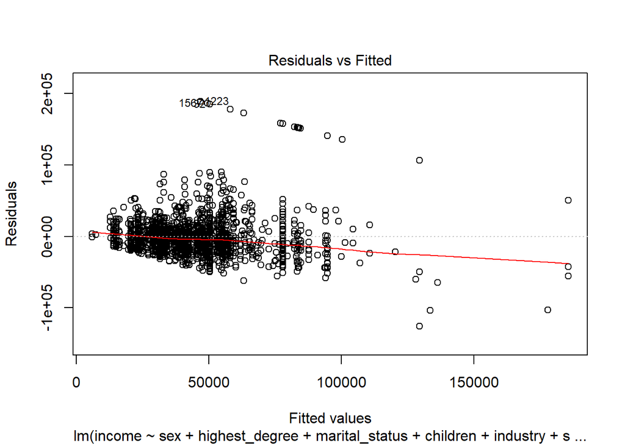

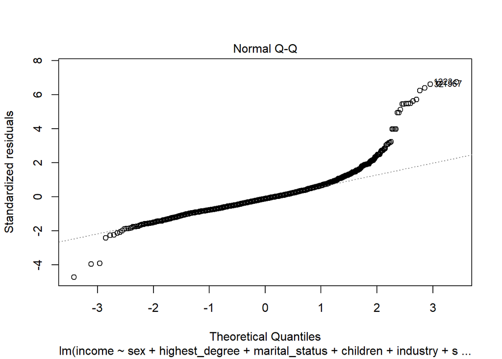

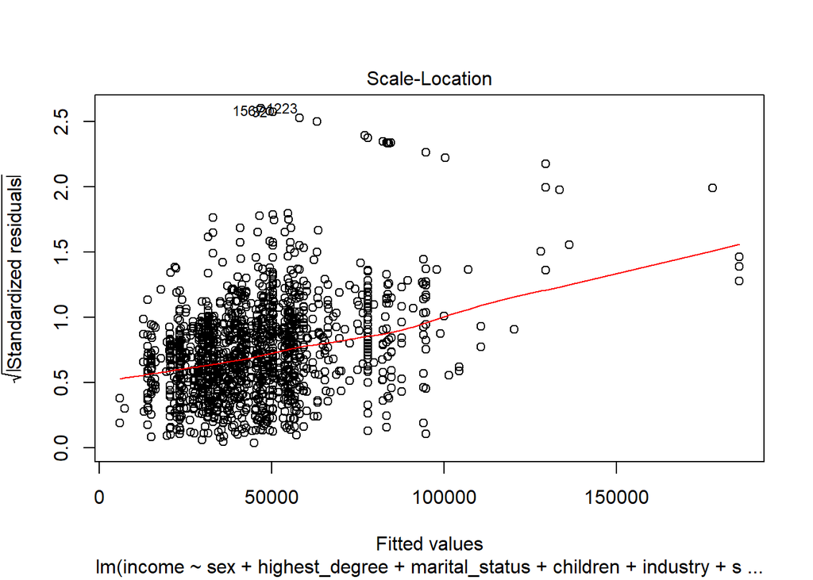

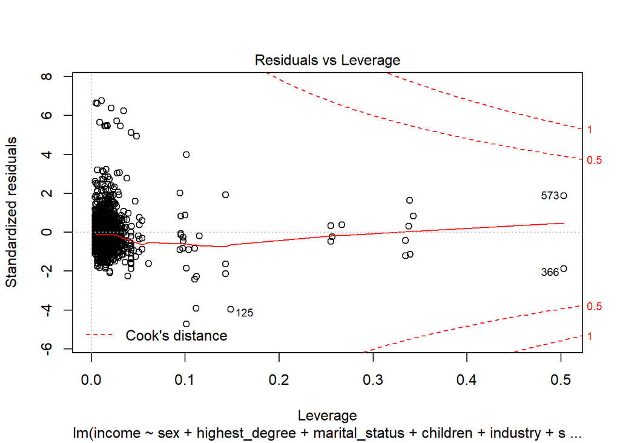

```r
plot(nlsy.lm.edu.interact)
```

> There is clear non-linearity, non-normal distribution, and heteroscedasticity of the model `nlsy.lm.edu.interact`. There are also a few outliers.

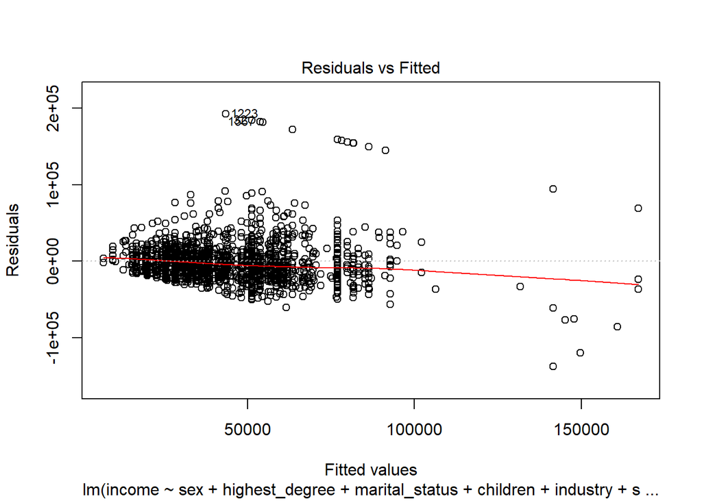

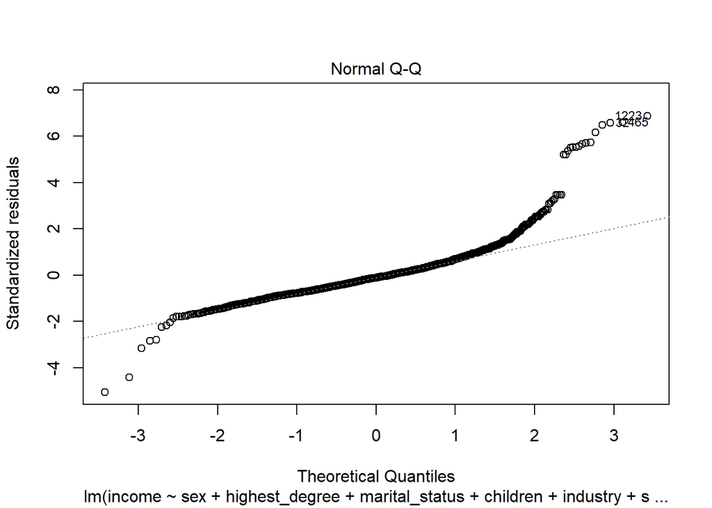

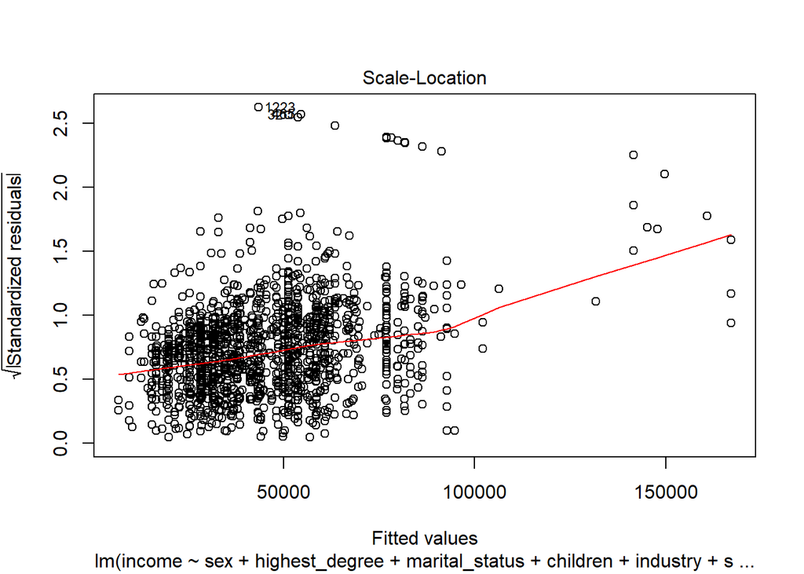

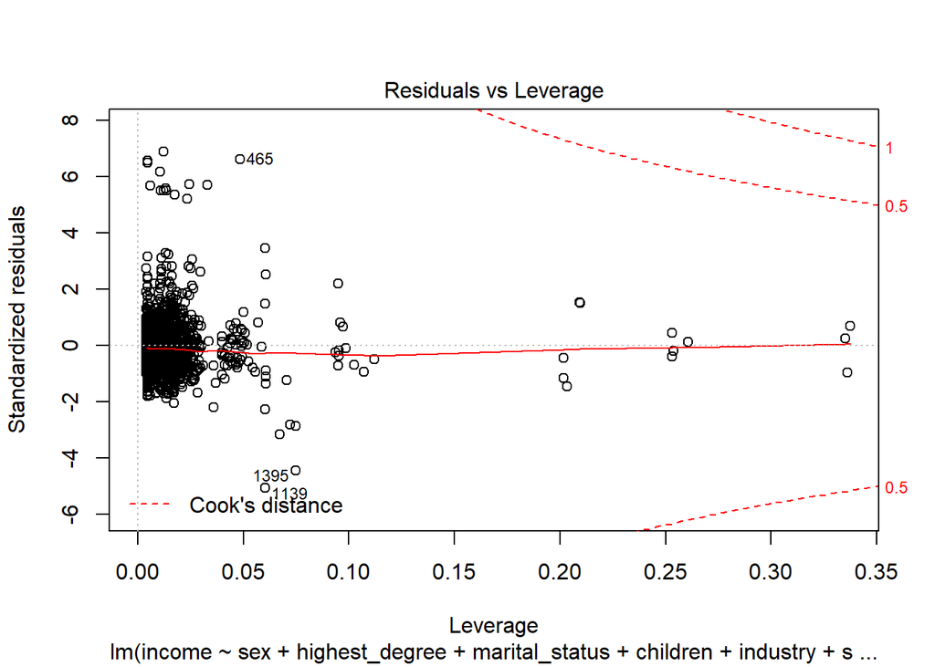

```r
plot(nlsy.lm.mari.interact)
```

> Similarly, there is clear non-linearity, non-normal distribution, and heteroscedasticity of the model `nlsy.lm.mari.interact`. There are also a few outliers.

> To solve the issues of non-linearity, non-normal distribution, heteroscedasticity and outliers, we are considering removing the 121 top-coded respondents who has the highest income and doing a log transformation for the income:

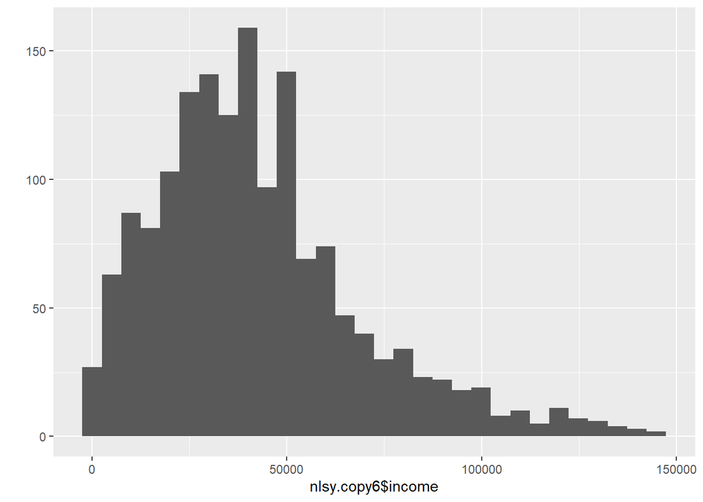

```r
nlsy.copy6 <- nlsy.copy5 %>% filter(!(nlsy.copy5$income == max(income, na.rm = TRUE)))
qplot(nlsy.copy6$income)
```

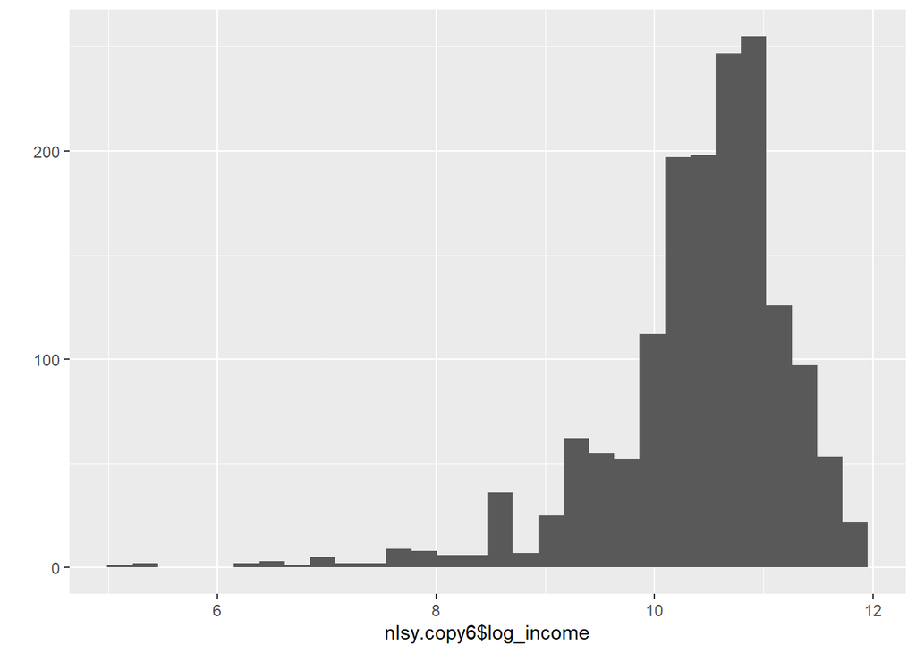

```r
nlsy.copy6$log_income <- log(nlsy.copy6$income)
qplot(nlsy.copy6$log_income)
```